# Dissociable effects of monetary, liquid, and social incentives on motivation and cognitive control

Jennifer Crawford

10.13.19

# Experiment I - Within-Subject Manipulation of both social (dynamic stim) and liquid feedback

```r
# Clear workspace
rm(list=ls())
# load libraries
library(kableExtra); library(ez); library(psych); library(knitr); library(RColorBrewer); library(tidyverse)
# summarySEwithin2 function
source("https://raw.githubusercontent.com/jlcrawford/SocFeedback/master/summarySEwithin2.R")
```

## Reward Rate Calculation

### Testing for differences (reward rate, accuracy, error rate) across incentive modalities

```r
#Import Data
data.path.sf <- "https://raw.githubusercontent.com/jlcrawford/SocFeedback/master/Experiment1/Data/SF_merged_FINAL.csv"
data.path.lf <- "https://raw.githubusercontent.com/jlcrawford/SocFeedback/master/Experiment1/Data/LF_merged_FINAL.csv"

data.reward.sf <-read.csv(data.path.sf, header = TRUE) %>%
    select(Subject, Trial, Condition, Target.RT, CriterionRT, Target.ACC, Target.RESP, Session, CorrectResponse, Reward, Procedure.Trial.) %>%
    mutate(IncentiveType="Social",
           Valence=factor(Condition, levels=c("P","T","N"), labels=c("Positive","Neutral","Negative")))

data.reward.lf <-read.csv(data.path.lf, header = TRUE) %>%
    select(Subject, Trial, Condition, Target.RT, CriterionRT, Target.ACC, Target.RESP, Session, CorrectResponse, Reward, Procedure.Trial.) %>%
    mutate(IncentiveType="Liquid",
           Valence=factor(Condition, levels=c("J","N","S"), labels=c("Positive","Neutral","Negative")))

feedback.merged <- rbind(data.reward.lf, data.reward.sf)

#Formatting the incentive data to include rewarded trials and error trials, as well as dummy (incentive type) and event (reward, valence) coding
feedback.merged <- feedback.merged %>%
  mutate(subRewarded = (Target.RT<CriterionRT & Target.ACC==1)*1,
      subError = (Target.ACC==0 & Target.RT>CriterionRT)*1,
      moneynumber = factor(Procedure.Trial., levels = c("Reward1","Reward2","Reward4"), labels = c(1,2,4)),
      moneyreward = factor(Procedure.Trial., levels = c("Reward1","Reward2","Reward4"), labels = c("$","$$","$$$$")),
      rewCode = factor(Procedure.Trial., levels=c("Reward1","Reward2","Reward4"), labels=c(-1,0,1)),
      valCode = factor(Valence, levels=c("Positive","Neutral","Negative"), labels=c(1,0,-1)),
      incentiveCode = factor(IncentiveType, levels=c("Social","Liquid"), labels=c(0,1)))
feedback.merged$rewCode <- as.numeric(levels(feedback.merged$rewCode)[feedback.merged$rewCode])
feedback.merged$valCode <- as.numeric(levels(feedback.merged$valCode)[feedback.merged$valCode])
feedback.merged$incentiveCode <- as.numeric(levels(feedback.merged$incentiveCode)[feedback.merged$incentiveCode])


#Grouping the Data by Condition
# Social vs. Liquid Feedback
incentive.means = group_by(feedback.merged, Subject, IncentiveType) %>% filter(!is.na(subRewarded)) %>%
  dplyr::summarise(n=n(), meanRR = mean(subRewarded), meanACC = mean(Target.ACC), meanErr = mean(subError))
incentive.RTmeans = group_by(feedback.merged, Subject, IncentiveType) %>% filter(!is.na(subRewarded) & Target.ACC==1) %>%
  dplyr::summarise(n=n(), meanRT = mean(Target.RT))

# Group by valence (Positive, Neutral, Negative)
val.means = group_by(feedback.merged, Subject, Valence) %>% filter(!is.na(subRewarded)) %>%
  dplyr::summarise(n=n(), meanRR = mean(subRewarded), meanACC = mean(Target.ACC), meanErr = mean(subError))
val.RTmeans = group_by(feedback.merged, Subject, Valence) %>% filter(!is.na(subRewarded) & Target.ACC==1) %>%
  dplyr::summarise(n=n(), meanRT = mean(Target.RT))

# Group by valence (Positive, Neutral, Negative) and incentive type (Social, Liquid)
val.inc.means = group_by(feedback.merged, Subject, Valence, IncentiveType) %>% filter(!is.na(subRewarded)) %>%
  dplyr::summarise(n=n(), meanRR = mean(subRewarded), meanACC = mean(Target.ACC), meanErr = mean(subError))
val.inc.RTmeans = group_by(feedback.merged, Subject, Valence, IncentiveType) %>% filter(!is.na(subRewarded) & Target.ACC==1) %>%
  dplyr::summarise(n=n(), meanRT = mean(Target.RT))

# Group by monetary reward ($, $$, $$$), valence (Positive, Neutral, Negative) and incentive type (Social, Liquid)
money.inc.means = group_by(feedback.merged, Subject, moneyreward, IncentiveType) %>% filter(!is.na(subRewarded)) %>%
  dplyr::summarise(n=n(), meanRR = mean(subRewarded), meanACC = mean(Target.ACC), meanErr = mean(subError))

val.inc.mon.means = group_by(feedback.merged, Subject, Valence,IncentiveType,moneyreward) %>% filter(!is.na(subRewarded)) %>%
  dplyr::summarise(n=n(), meanRR = mean(subRewarded), sdRR = sd(subRewarded), meanACC = mean(Target.ACC), sdACC = sd(Target.ACC),
                   meanErr = mean(subError), sdErr = sd(subError))
val.inc.mon.RTmeans = group_by(feedback.merged, Subject, Valence, IncentiveType,moneyreward) %>% filter(!is.na(subRewarded) & Target.ACC==1) %>%
  dplyr::summarise(n=n(), meanRT = mean(Target.RT))
val.inc.mon.means<-data.frame(val.inc.mon.means)

#Reward Rate Difference Across Social and Liquid Feedback
t.test(x = subset(incentive.means, IncentiveType=="Social")$meanRR,
       y = subset(incentive.means, IncentiveType=="Liquid")$meanRR,
       paired = TRUE)
```

```
##
##  Paired t-test
##
## data:  subset(incentive.means, IncentiveType == "Social")$meanRR and subset(incentive.means, IncentiveType == "Liquid")$meanRR
## t = 0.99652, df = 30, p-value = 0.327
## alternative hypothesis: true difference in means is not equal to 0
## 95 percent confidence interval:
##  -0.02997278  0.08709644
## sample estimates:
## mean of the differences
##              0.02856183
```

```r
S.mean.RR = mean(subset(incentive.means, IncentiveType=="Social")$meanRR)
L.mean.RR = mean(subset(incentive.means, IncentiveType=="Liquid")$meanRR)

#Accuracy Difference Across Social and Liquid Feedback
t.test(x = subset(incentive.means, IncentiveType=="Social")$meanACC,
       y = subset(incentive.means, IncentiveType=="Liquid")$meanACC,
       paired = TRUE)
```

```
##
##  Paired t-test
##
## data:  subset(incentive.means, IncentiveType == "Social")$meanACC and subset(incentive.means, IncentiveType == "Liquid")$meanACC
## t = 2.2607, df = 30, p-value = 0.03119
## alternative hypothesis: true difference in means is not equal to 0
## 95 percent confidence interval:
##  0.003387375 0.066729113
## sample estimates:
## mean of the differences
##              0.03505824
```

```r
S.mean.ACC = mean(subset(incentive.means, IncentiveType=="Social")$meanACC)
L.mean.ACC = mean(subset(incentive.means, IncentiveType=="Liquid")$meanACC)

#Error Rate Difference Across Social and Liquid Feedback
t.test(x = subset(incentive.means, IncentiveType=="Social")$meanErr,
       y = subset(incentive.means, IncentiveType=="Liquid")$meanErr,
       paired = TRUE)
```

```
##
##  Paired t-test
##
## data:  subset(incentive.means, IncentiveType == "Social")$meanErr and subset(incentive.means, IncentiveType == "Liquid")$meanErr
## t = -0.53346, df = 30, p-value = 0.5976
## alternative hypothesis: true difference in means is not equal to 0
## 95 percent confidence interval:
##  -0.015683413  0.009186997
## sample estimates:
## mean of the differences
##            -0.003248208
```

```r
S.mean.Err = mean(subset(incentive.means, IncentiveType=="Social")$meanErr)
L.mean.Err = mean(subset(incentive.means, IncentiveType=="Liquid")$meanErr)
```

### Summary Table of Reward Rate, Accuracy, Error Rate, and RT

```r
#Summary Table of Rewrard Rate, Accuracy, Error Rate, and RT
RR.summary<-summarySEwithin2(data = val.inc.mon.means, measurevar = "meanRR", withinvars = c("Valence","IncentiveType","moneyreward"), idvar = "Subject")
ACC.sum <-summarySEwithin2(data = val.inc.mon.means, measurevar = "meanACC", withinvars = c("Valence","IncentiveType","moneyreward"), idvar = "Subject") %>%
  rename("ACC_mean" =  meanACC,
         "ACC_sd" = sd) %>%
  select(ACC_mean, ACC_sd)

Err.sum <- summarySEwithin2(data = val.inc.mon.means, measurevar = "meanErr", withinvars = c("Valence","IncentiveType","moneyreward"), idvar = "Subject") %>%
   rename("Err_mean" = meanErr,
         "Err_sd" = sd) %>%
  select(Err_mean, Err_sd)

RT.sum <- summarySEwithin2(data = val.inc.mon.RTmeans, measurevar = "meanRT", withinvars = c("Valence","IncentiveType","moneyreward"), idvar = "Subject") %>%
   rename("RT_mean" = meanRT,
         "RT_sd" = sd) %>%
  select(RT_mean, RT_sd)

summary.table <- cbind(RR.summary,ACC.sum, Err.sum, RT.sum) %>%
  rename("RR_mean" = meanRR,
         "RR_sd" = sd) %>%
  select(-c("N","meanRRNormed","se","ci"))

###Summary Table: Reward Rate, Accuracy, Error Rate, RT
summary.table$moneyreward <- factor(summary.table$moneyreward, levels = c("$","$$","$$$$"), labels = c("Low","Medium","High"))
tab.RR.sum <- summary.table %>%
  pivot_wider(names_from = "IncentiveType", values_from = c("RR_mean","RR_sd","ACC_mean","ACC_sd","Err_mean","Err_sd",
                                                            "RT_mean","RT_sd")) %>%
  select(Valence, moneyreward, RR_mean_Liquid, RR_sd_Liquid, ACC_mean_Liquid, ACC_sd_Liquid, Err_mean_Liquid, Err_sd_Liquid, RT_mean_Liquid, RT_sd_Liquid,
         RR_mean_Social, RR_sd_Social, ACC_mean_Social, ACC_sd_Social, Err_mean_Social, Err_sd_Social, RT_mean_Social, RT_sd_Social)  %>%
  kable(., format = "html", digits = 3, booktabs = T,
        col.names = c("Feedback Valence", "Monetary Reward", rep(c("Mean","SD"), times = 8)),
        caption = "Task Performance Variables") %>%
  kable_styling(full_width = F) %>%
  add_header_above(c(" " = 2, "Reward Rate" = 2, "Accuracy" = 2, "Error Rate" = 2, "Reaction Time" = 2,
                   "Reward Rate" = 2, "Accuracy" = 2, "Error Rate" = 2, "Reaction Time" = 2)) %>%
  add_header_above(c(" " = 2, "Liquid" = 8, "Social" = 8)) %>%
  pack_rows("Negative", 1, 3) %>%
  pack_rows("Neutral", 4, 6) %>%
  pack_rows("Positive", 7, 9)
tab.RR.sum
```

Task Performance Variables

| Feedback Valence | Monetary Reward | Liquid Reward Rate Mean | Liquid Reward Rate SD | Liquid Accuracy Mean | Liquid Accuracy SD | Liquid Error Rate Mean | Liquid Error Rate SD | Liquid Reaction Time Mean | Liquid Reaction Time SD | Social Reward Rate Mean | Social Reward Rate SD | Social Accuracy Mean | Social Accuracy SD | Social Error Rate Mean | Social Error Rate SD | Social Reaction Time Mean | Social Reaction Time SD |
| --- | --- | --- | --- | --- | --- | --- | --- | --- | --- | --- | --- | --- | --- | --- | --- | --- | --- |
| **Negative** |  |  |  |  |  |  |  |  |  |  |  |  |  |  |  |  |  |
| Negative | Low | 0.560 | 0.183 | 0.774 | 0.120 | 0.045 | 0.037 | 516.466 | 105.781 | 0.657 | 0.122 | 0.837 | 0.100 | 0.037 | 0.046 | 485.989 | 50.971 |
| Negative | Medium | 0.556 | 0.185 | 0.796 | 0.139 | 0.049 | 0.050 | 525.400 | 96.434 | 0.669 | 0.092 | 0.860 | 0.072 | 0.038 | 0.033 | 488.338 | 71.513 |
| Negative | High | 0.626 | 0.173 | 0.810 | 0.145 | 0.041 | 0.051 | 477.587 | 76.576 | 0.676 | 0.102 | 0.835 | 0.057 | 0.025 | 0.039 | 471.212 | 57.764 |
| **Neutral** |  |  |  |  |  |  |  |  |  |  |  |  |  |  |  |  |  |
| Neutral | Low | 0.650 | 0.123 | 0.839 | 0.065 | 0.046 | 0.041 | 483.647 | 72.863 | 0.622 | 0.138 | 0.829 | 0.088 | 0.040 | 0.038 | 494.031 | 58.394 |
| Neutral | Medium | 0.609 | 0.138 | 0.829 | 0.079 | 0.040 | 0.035 | 496.988 | 81.683 | 0.649 | 0.124 | 0.869 | 0.069 | 0.045 | 0.038 | 499.539 | 56.108 |
| Neutral | High | 0.693 | 0.111 | 0.831 | 0.087 | 0.028 | 0.038 | 458.348 | 58.663 | 0.688 | 0.099 | 0.861 | 0.051 | 0.022 | 0.032 | 471.298 | 46.767 |
| **Positive** |  |  |  |  |  |  |  |  |  |  |  |  |  |  |  |  |  |
| Positive | Low | 0.660 | 0.120 | 0.818 | 0.092 | 0.032 | 0.031 | 461.462 | 67.753 | 0.644 | 0.125 | 0.849 | 0.087 | 0.045 | 0.038 | 491.220 | 51.494 |
| Positive | Medium | 0.642 | 0.102 | 0.815 | 0.080 | 0.048 | 0.031 | 471.622 | 71.874 | 0.628 | 0.128 | 0.853 | 0.102 | 0.046 | 0.062 | 496.927 | 51.733 |
| Positive | High | 0.686 | 0.105 | 0.835 | 0.101 | 0.024 | 0.029 | 453.610 | 56.001 | 0.707 | 0.106 | 0.870 | 0.073 | 0.026 | 0.033 | 468.047 | 44.320 |

### Figure 2: Incentive Integration Effects across Social & Liquid Feedback

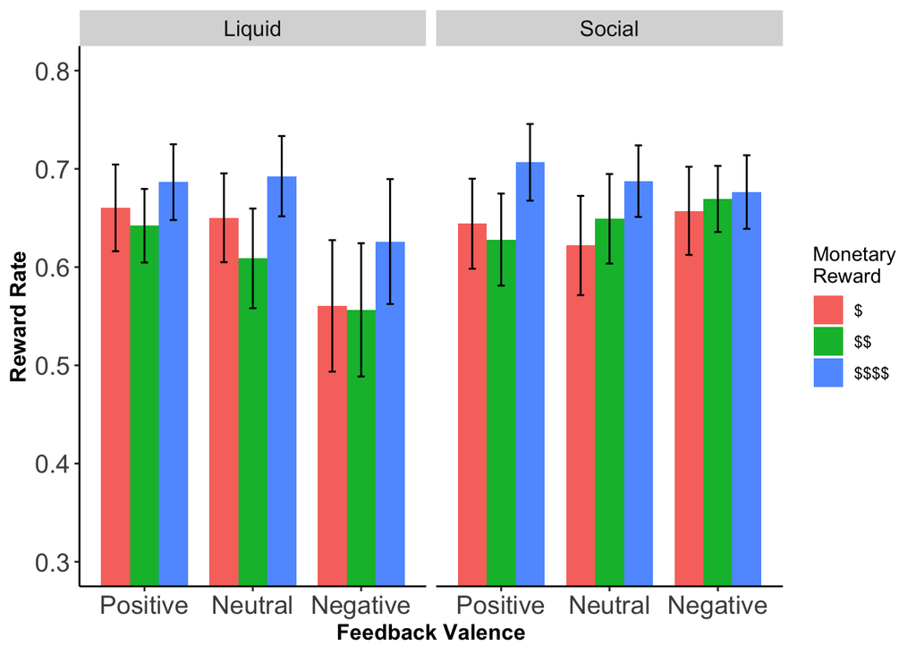

```r
#Plotting reward rate across Social + Liquid feedback by Valence and Monetary Reward (Figure 2)
RR.sum<-summarySEwithin2(data = val.inc.mon.means, measurevar = "meanRR", withinvars = c("Valence","IncentiveType","moneyreward"), idvar = "Subject")
RR.sum$Valence<-factor(x = RR.sum$Valence, levels=c("Positive","Neutral","Negative")) # change order of factors for axis labels
p.RR.Exp1<-ggplot(RR.sum, aes(x=Valence, y=meanRR, fill=moneyreward)) +
  geom_bar(position=position_dodge(width=0.8), stat="identity", width=0.8) +
  geom_errorbar(position=position_dodge(width=0.8), aes(ymin=meanRR-ci, ymax=meanRR+ci), width=.2) +
  labs(x="Feedback Valence",y="Reward Rate") +
  scale_x_discrete(labels=c("Positive","Neutral","Negative")) +
  scale_fill_discrete(name="Monetary\nReward") +
  coord_cartesian(ylim=c(.3,.80)) +
    theme(plot.title = element_text(hjust = 0.5), panel.grid.major = element_blank(), panel.grid.minor = element_blank(), panel.background = element_blank(), axis.line = element_line(colour = "black"),
    axis.title=element_text(size=12,face = "bold"),
    axis.text=element_text(size=14),
    legend.position="right",
    strip.text.x = element_text(size = 12)) +
  facet_grid(.~IncentiveType)
p.RR.Exp1
```

### ANOVA Tables: Monetary Reward x Feedback Valence x Incentive Session

```r
#Omnibus ANOVA (Incentive Type x Valence x Monetary Reward)
omnibus.anova.E1<-ezANOVA(data = val.inc.mon.means, dv = meanRR, wid = .(Subject), within = c("Valence","IncentiveType","moneyreward"))
d.anova.E1 <- omnibus.anova.E1$ANOVA %>%
  mutate(Effect = factor(Effect, levels = c("Valence","IncentiveType","moneyreward","Valence:IncentiveType",
                                            "Valence:moneyreward","IncentiveType:moneyreward","Valence:IncentiveType:moneyreward"),
                         labels = c("Feedback Valence","Incentive Type","Monetary Reward","Feedback Valence x Incentive Type","Feedback Valence x Monetary Reward",
                                    "Incentive Type x Monetary Reward", "Feedback Valence x Incentive Type x Monetary Reward"))) %>%
  rename("Generalized Eta Squared" = ges)
tab.omnibus.E1 <- kable(d.anova.E1, format = "html", digits = 3, caption = "Monetary Reward x Feedback Valence x Incentive Session -- Experiment I") %>%
  kable_styling(bootstrap_options = "striped", full_width = F)
tab.omnibus.E1
```

Monetary Reward x Feedback Valence x Incentive Session – Experiment I

Effect

DFn

DFd

F

p

p<.05

Generalized Eta Squared

Feedback Valence

2

60

2.824

0.067

0.010

Incentive Type

1

30

0.993

0.327

0.009

Monetary Reward

2

60

18.531

0.000

0.024

Feedback Valence x Incentive Type

2

60

5.662

0.006

0.018

Feedback Valence x Monetary Reward

4

120

0.525

0.718

0.001

Incentive Type x Monetary Reward

2

60

2.132

0.127

0.002

Feedback Valence x Incentive Type x Monetary Reward

4

120

2.281

0.065

0.005

```r
#Social Feedback ANOVA (Valence x Monetary Reward)
social.anova.E1<-ezANOVA((data = val.inc.mon.means %>% filter(IncentiveType== "Social")), dv = meanRR, wid = .(Subject), within = c("Valence","moneyreward"))
d.soc.anova.E1 <- social.anova.E1$ANOVA %>%
  mutate(Effect = factor(Effect, levels = c("Valence","moneyreward","Valence:moneyreward"),
                         labels = c("Feedback Valence","Monetary Reward","Feedback Valence x Monetary Reward"))) %>%
  rename("Generalized Eta Squared" = ges)
tab.soc.E1 <- kable(d.soc.anova.E1, digits = 3, caption = "Social Feedback ANOVA (Feedback Valence x Monetary Reward)") %>%
  kable_styling(bootstrap_options = "striped", full_width = F)
tab.soc.E1
```

Social Feedback ANOVA (Feedback Valence x Monetary Reward)

Effect

DFn

DFd

F

p

p<.05

Generalized Eta Squared

Feedback Valence

2

60

0.513

0.601

0.002

Monetary Reward

2

60

9.144

0.000

0.024

Feedback Valence x Monetary Reward

4

120

2.175

0.076

0.009

```r
#Liquid Feedback ANOVA (Valence x Monetary Reward)
liquid.anova.E1<-ezANOVA((data = val.inc.mon.means %>% filter(IncentiveType== "Liquid")), dv = meanRR, wid = .(Subject), within = c("Valence","moneyreward"))
d.liq.anova.E1 <-liquid.anova.E1$ANOVA %>%
  mutate(Effect = factor(Effect, levels = c("Valence","moneyreward","Valence:moneyreward"),
                         labels = c("Feedback Valence","Monetary Reward","Feedback Valence x Monetary Reward"))) %>%
  rename("Generalized Eta Squared" = ges)
tab.liq.E1 <- kable(d.liq.anova.E1, digits = 3, caption = "Liquid Feedback ANOVA (Feedback Valence x Monetary Reward)") %>%
  kable_styling(bootstrap_options = "striped", full_width = F)
tab.liq.E1
```

Liquid Feedback ANOVA (Feedback Valence x Monetary Reward)

Effect

DFn

DFd

F

p

p<.05

Generalized Eta Squared

Feedback Valence

2

60

5.160

0.009

0.045

Monetary Reward

2

60

15.527

0.000

0.027

Feedback Valence x Monetary Reward

4

120

0.813

0.519

0.003

## Affect Ratings

```r
# Format Affect Rating Data
affect.sf <- read.csv(data.path.sf, header = TRUE) %>% select(Subject, Trial, Condition, Feeling, Ratings.RESP, Ratings.RT, Procedure.Trial.) %>%
  mutate(IncentiveType="Social",
         Valence=factor(Condition, levels=c("P","T","N"), labels=c("Positive","Neutral","Negative"))) %>%
  filter(Procedure.Trial. == "RatingsTask")

affect.lf <- read.csv(data.path.lf, header = TRUE) %>% select(Subject, Trial, Condition, Feeling, Ratings.RESP, Ratings.RT, Procedure.Trial.) %>%
  mutate(IncentiveType="Liquid",
         Valence=factor(Condition, levels=c("J","N","S"), labels=c("Positive","Neutral","Negative"))) %>%
  filter(Procedure.Trial. == "RatingsTask")

affect.merged <- rbind(affect.sf,affect.lf)

#Calc avg affective ratings
word.means <- affect.merged %>% select(Subject, Valence, Feeling, Ratings.RESP, Ratings.RT, IncentiveType) %>%
  group_by(Subject,Valence,Feeling,IncentiveType) %>%
  dplyr::summarise(meanRating = mean(Ratings.RESP, na.rm = TRUE), meanRT = mean(Ratings.RT))

word.means.sum <- summarySEwithin2(data=word.means, measurevar = "meanRating", withinvars = c("Valence", "Feeling", "IncentiveType"), idvar = "Subject")

#Calc averge affect ratings collapsed by valence
word.means.pos<- affect.merged %>% select(Subject, Valence, Feeling, Ratings.RESP, Ratings.RT, IncentiveType) %>%
   filter(str_detect(Feeling, "Content|Inspired|Excited")) %>%
  mutate(Word_Valence = "Positive") %>%
  group_by(Subject,Valence,Word_Valence,IncentiveType) %>%
  dplyr::summarise(meanRating = mean(Ratings.RESP, na.rm = TRUE), meanRT = mean(Ratings.RT))

word.means.neg <- affect.merged %>% select(Subject, Valence, Feeling, Ratings.RESP, Ratings.RT, IncentiveType) %>%
   filter(str_detect(Feeling, "Ashamed|Irritable|Upset")) %>%
  mutate(Word_Valence = "Negative") %>%
  group_by(Subject,Valence,Word_Valence,IncentiveType) %>%
  dplyr::summarise(meanRating = mean(Ratings.RESP, na.rm = TRUE), meanRT = mean(Ratings.RT))

word.means.valence <- rbind(word.means.pos, word.means.neg)
word.means.valence.sum <- summarySEwithin2(data=word.means.valence, measurevar = "meanRating", withinvars = c("Valence","Word_Valence","IncentiveType"), idvar = "Subject")
word.means.valence.sum$Word_Valence <- factor(word.means.valence.sum$Word_Valence, levels = c("Positive", "Negative"))
word.means.valence.sum$Valence <- factor(word.means.valence.sum$Valence , levels = c("Positive", "Neutral", "Negative"))
```

### Figure 3: Post-block Affect Ratings Across Social & Liquid Feedback Conditions

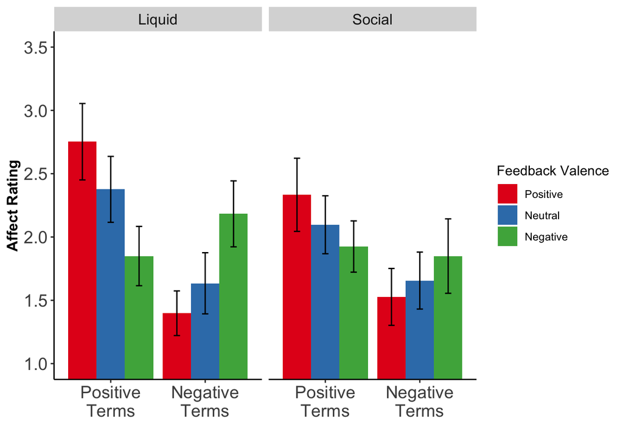

```r
#Plot affect ratings (Figure 3)
p.affect.valence <- ggplot(word.means.valence.sum, aes(x=Word_Valence, y=meanRating, fill=Valence)) +
  coord_cartesian(ylim = c(1,3.5)) +
    theme(plot.title = element_text(hjust = 0.5), panel.grid.major = element_blank(), panel.grid.minor = element_blank(), panel.background = element_blank(), axis.line = element_line(colour = "black"),
    axis.title=element_text(size=12,face = "bold"),
    axis.text=element_text(size=14),
    legend.position="right",
    strip.text.x = element_text(size = 12)) +
  geom_bar(stat="identity", position=position_dodge()) +
  geom_errorbar(position=position_dodge(width=0.9), aes(ymin=meanRating-ci, ymax=meanRating+ci), width=.2) +
   scale_fill_brewer(palette="Set1", name="Feedback Valence", breaks=c("Positive", "Neutral", "Negative"), labels=c("Positive", "Neutral", "Negative")) +
  xlab("") + ylab("Affect Rating") +
  scale_x_discrete(labels=c("Positive" = "Positive\nTerms", "Negative" = "Negative\nTerms")) +
  facet_grid(.~IncentiveType)
p.affect.valence
```

### Affect Ratings: Summary Table

```r
tab.affect.sum <- word.means.valence.sum %>% select(Valence, Word_Valence, IncentiveType, meanRating, sd) %>%
  pivot_wider(names_from = "IncentiveType", values_from = c("meanRating","sd")) %>%
  select(Valence, Word_Valence, meanRating_Liquid, sd_Liquid, meanRating_Social, sd_Social) %>%
  kable(., format = "html", digits = 3, booktabs = T,
        col.names = c("Feedback Valence", "Affect Term Valence", rep(c("Mean","SD"), times = 2)),
        caption = "Post-Block Affect Ratings") %>%
  kable_styling(full_width = F) %>%
  add_header_above(c(" " = 2, "Liquid" = 2, "Social" = 2)) %>%
  pack_rows("Negative", 1, 2) %>%
  pack_rows("Neutral", 3, 4) %>%
  pack_rows("Positive", 5, 6)
tab.affect.sum
```

Post-Block Affect Ratings

| Feedback Valence | Affect Term Valence | Liquid Mean | Liquid SD | Social Mean | Social SD |
| --- | --- | --- | --- | --- | --- |
| **Negative** |  |  |  |  |  |
| Negative | Negative | 2.183 | 0.710 | 1.849 | 0.802 |
| Negative | Positive | 1.849 | 0.638 | 1.925 | 0.552 |
| **Neutral** |  |  |  |  |  |
| Neutral | Negative | 1.634 | 0.658 | 1.656 | 0.613 |
| Neutral | Positive | 2.376 | 0.710 | 2.097 | 0.624 |
| **Positive** |  |  |  |  |  |
| Positive | Negative | 1.398 | 0.481 | 1.527 | 0.613 |
| Positive | Positive | 2.753 | 0.823 | 2.333 | 0.788 |

### ANOVA Tables: Incentive Type x Affect Term Valence x Feedback Valence

```r
#Testing for effects of incentive type, affect term valence, and the motivational valence of the stimuli on affect rating
#Omnibus ANOVA (Incentive Type x Word Valence x Motivational Valence)
affect.anova<-ezANOVA(data = word.means.valence, dv = meanRating, wid = .(Subject), within = c("Word_Valence","Valence","IncentiveType"))
affect.anova.E1 <- affect.anova$ANOVA %>%
    mutate(Effect = factor(Effect, levels = c("Word_Valence","Valence","IncentiveType","Word_Valence:Valence","Word_Valence:IncentiveType",
                                              "Valence:IncentiveType","Word_Valence:Valence:IncentiveType"),
            labels = c("Affect Term Valence","Feedback Valence","Incentive Type", "Affect Term Valence x Feedback Valence",
                      "Affect Term Valence x Incentive Type", "Feedback Valence x Incentive Type","Affect Term Valence x Feedback Valence x Incentive Type"))) %>%
  rename("Generalized Eta Squared" = ges)
tab.affect <- kable(affect.anova.E1, digits = 3, caption = "Omnibus ANOVA (Incentive Type x Word Valence x Feedback Valence)") %>%
  kable_styling(bootstrap_options = "striped", full_width = F)
tab.affect
```

Omnibus ANOVA (Incentive Type x Word Valence x Feedback Valence)

Effect

DFn

DFd

F

p

p<.05

Generalized Eta Squared

Affect Term Valence

1

30

17.542

0.000

0.092

Feedback Valence

2

60

0.743

0.480

0.001

Incentive Type

1

30

2.401

0.132

0.007

Affect Term Valence x Feedback Valence

2

60

26.204

0.000

0.087

Affect Term Valence x Incentive Type

1

30

1.097

0.303

0.002

Feedback Valence x Incentive Type

2

60

0.017

0.983

0.000

Affect Term Valence x Feedback Valence x Incentive Type

2

60

4.237

0.019

0.016

```r
#Social Feedback ANOVA (Word Valence x Motivational Valence)
social.affect.anova<-ezANOVA((data = word.means.valence %>% filter(IncentiveType== "Social")), dv = meanRating, wid = .(Subject), within = c("Word_Valence","Valence"))
affect.soc.anova.E1 <- social.affect.anova$ANOVA %>%
  mutate(Effect = factor(Effect, levels = c("Word_Valence","Valence","Word_Valence:Valence"),
                         labels = c("Affect Term Valence","Feedback Valence","Affect Term Valence x Feedback Valence"))) %>%
  rename("Generalized Eta Squared" = ges)
tab.soc.affect <- kable(affect.soc.anova.E1, digits = 3, caption = "Social Feedback ANOVA (Word Valence x Feedback Valence)") %>%
  kable_styling(bootstrap_options = "striped", full_width = F)
tab.soc.affect
```

Social Feedback ANOVA (Word Valence x Feedback Valence)

Effect

DFn

DFd

F

p

p<.05

Generalized Eta Squared

Affect Term Valence

1

30

11.359

0.002

0.067

Feedback Valence

2

60

0.285

0.753

0.001

Affect Term Valence x Feedback Valence

2

60

4.205

0.020

0.032

```r
#Liquid Feedback ANOVA (Word Valence x Motivational Valence)
liquid.affect.anova<-ezANOVA((data = word.means.valence %>% filter(IncentiveType== "Liquid")), dv = meanRating, wid = .(Subject), within = c("Word_Valence","Valence"))
affect.liq.anova.E1 <-liquid.affect.anova$ANOVA %>%
    mutate(Effect = factor(Effect, levels = c("Word_Valence","Valence","Word_Valence:Valence"),
                         labels = c("Affect Term Valence","Feedback Valence","Affect Term Valence x Feedback Valence"))) %>%
  rename("Generalized Eta Squared" = ges)
tab.liq.affect <- kable(affect.liq.anova.E1, digits = 3, caption = "Liquid Feedback ANOVA (Word Valence x Feedback Valence)") %>%
  kable_styling(bootstrap_options = "striped", full_width = F)
tab.liq.affect
```

Liquid Feedback ANOVA (Word Valence x Feedback Valence)

Effect

DFn

DFd

F

p

p<.05

Generalized Eta Squared

Affect Term Valence

1

30

15.094

0.001

0.122

Feedback Valence

2

60

0.549

0.581

0.002

Affect Term Valence x Feedback Valence

2

60

28.530

0.000

0.164

## Supplemental Material

### Reward Rate, Accuracy, Error Rate, & RT Across Sessions & Incentive Modalities

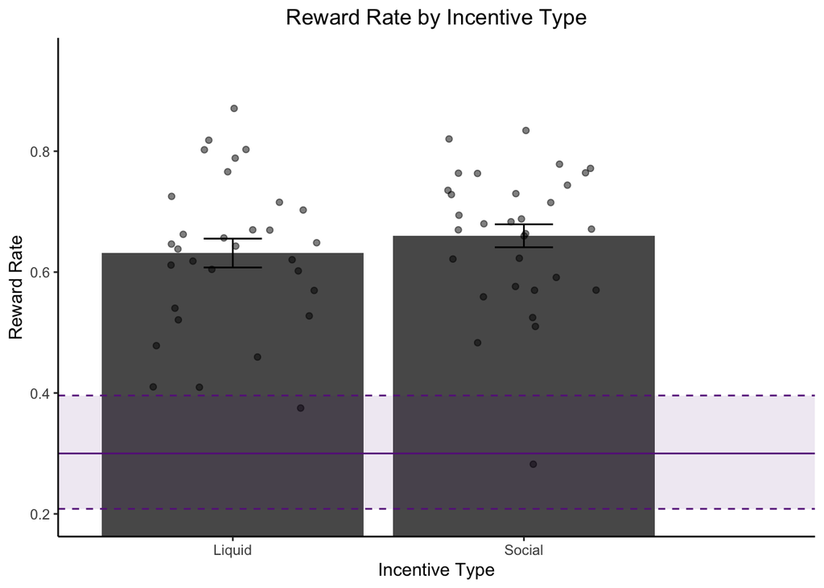

```r
#Summarizing Reward Rate, Accuracy, and RT by Session
#First Session
Session1.incentive <- feedback.merged %>% group_by(Subject,Session,IncentiveType,rewCode,CriterionRT) %>%
  filter(!is.na(subRewarded)) %>% filter(Session == 7 | Session == 8 | Session == 9) %>%
  dplyr::summarise(meanRR = mean(subRewarded), meanACC = mean(Target.ACC), meanErr = mean(subError), meanRT = mean(Target.RT)) %>%
  mutate(Visit = "First")

#Second Session
Session2.incentive <- feedback.merged %>% group_by(Subject,Session,IncentiveType,rewCode,CriterionRT) %>%
  filter(!is.na(subRewarded)) %>% filter(Session == 16 | Session == 17 | Session == 18) %>%
  dplyr::summarise(meanRR = mean(subRewarded), meanACC = mean(Target.ACC), meanErr = mean(subError), meanRT = mean(Target.RT)) %>%
  mutate(Visit = "Second")

Session.RR <- rbind(Session1.incentive,Session2.incentive)

#Plotting Reward Rate across incentive modalities (sessions) with individual means (dots)
reward_crit_low<-qbinom(p = .025, size = 96, prob = .3)/96
reward_crit_high<-qbinom(p = .975, size = 96, prob = .3)/96

m.RR.sum=summarySEwithin2(Session.RR, measurevar = "meanRR",
                        withinvars = "IncentiveType",
                        idvar = "Subject")

p.Session.RR.ind <- ggplot(data = m.RR.sum, aes(x=IncentiveType, y=meanRR)) +
           geom_bar(stat="identity", position=position_dodge()) +
  geom_errorbar(data = m.RR.sum, position=position_dodge(width=0.9), aes(ymin=meanRR-ci, ymax=meanRR+ci), width=.2) +
  geom_point(data = incentive.means, aes(x=IncentiveType, y=meanRR),
             stat="identity", position=position_jitter(w=.3), alpha=0.5) +
  geom_hline(yintercept = .3, color="darkorchid4") +
  geom_hline(yintercept = reward_crit_low, color="darkorchid4", linetype="dashed") +
  geom_hline(yintercept = reward_crit_high, color="darkorchid4", linetype="dashed") +
  geom_rect(mapping = aes(xmin=.4,xmax=3,ymin=reward_crit_low,ymax=reward_crit_high), fill="darkorchid4", alpha=0.05) +
   theme(plot.title = element_text(hjust = 0.5), panel.grid.major = element_blank(), panel.grid.minor = element_blank(), panel.background = element_blank(), axis.line = element_line(colour = "black")) +
  coord_cartesian(ylim=c(.2,.95)) +
  xlab("Incentive Type") + ylab("Reward Rate") + ggtitle("Reward Rate by Incentive Type")
p.Session.RR.ind
```

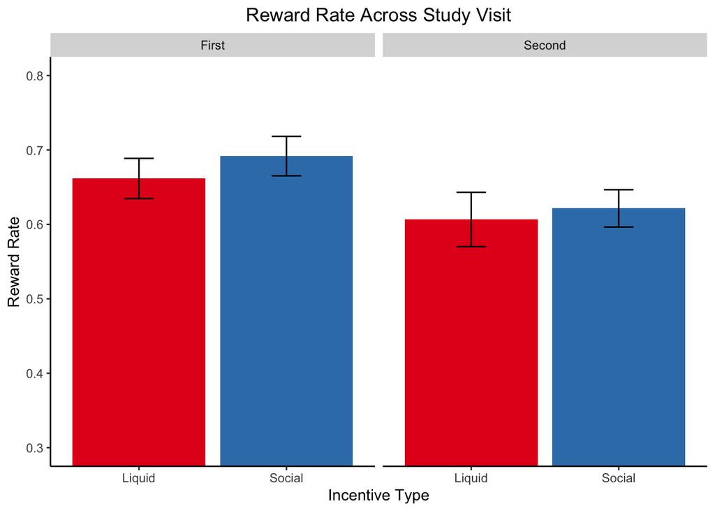

```r
#Reward Rate by Session
RR.session.sum=summarySEwithin2(Session.RR, measurevar = "meanRR",
                        withinvars = "IncentiveType", betweenvars = "Visit",
                        idvar = "Subject")

p.Session.RR <- ggplot(RR.session.sum, aes(x=IncentiveType, y=meanRR, fill=IncentiveType)) +
  theme(plot.title = element_text(hjust = 0.5), panel.grid.major = element_blank(), panel.grid.minor = element_blank(), panel.background = element_blank(), axis.line = element_line(colour = "black"), legend.position = "none") +
  geom_bar(stat="identity", position=position_dodge()) +
  geom_errorbar(position=position_dodge(width=0.9), aes(ymin=meanRR-ci, ymax=meanRR+ci), width=.2) +
  coord_cartesian(ylim=c(.3,.8)) +
  xlab("Incentive Type") + ylab("Reward Rate") +ggtitle("Reward Rate Across Study Visit") +
  scale_fill_brewer(palette="Set1", name="Incentive Type") +
  facet_grid(.~Visit)
p.Session.RR
```

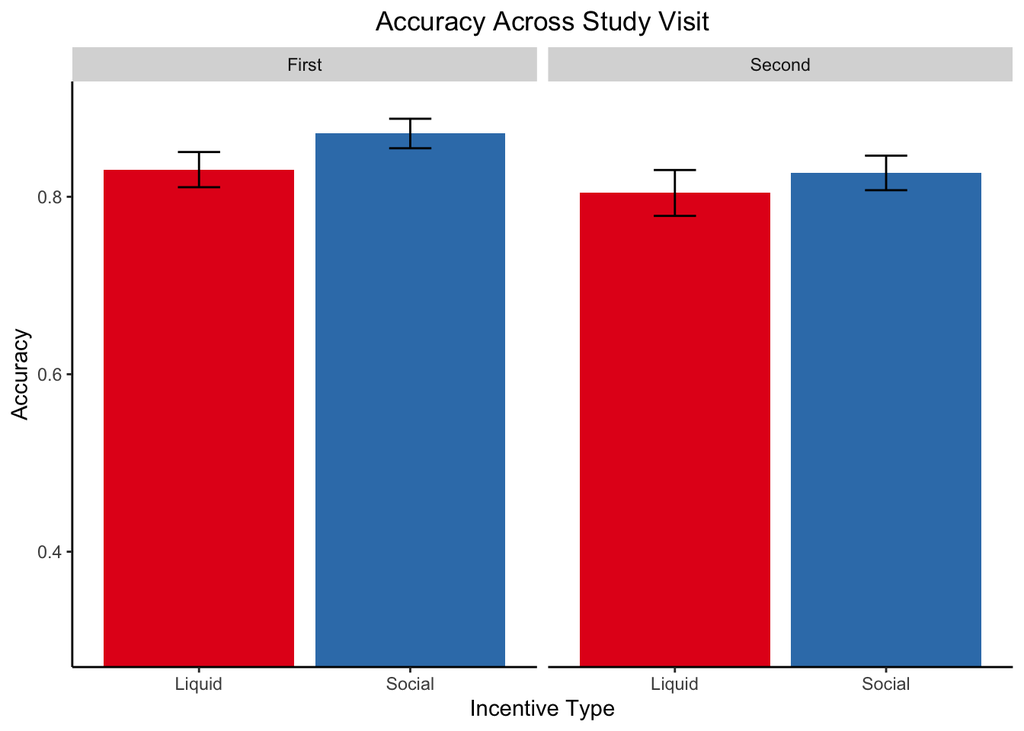

```r
#Summarizing Accuracy by Session
ACC.session.sum=summarySEwithin2(Session.RR, measurevar = "meanACC",
                        withinvars = "IncentiveType",betweenvars = "Visit",
                        idvar = "Subject")

p.Session.ACC <- ggplot(ACC.session.sum, aes(x=IncentiveType, y=meanACC, fill=IncentiveType)) +
  theme(plot.title = element_text(hjust = 0.5), panel.grid.major = element_blank(), panel.grid.minor = element_blank(), panel.background = element_blank(), axis.line = element_line(colour = "black"), legend.position = "none") +
  geom_bar(stat="identity", position=position_dodge()) +
  geom_errorbar(position=position_dodge(width=0.9), aes(ymin=meanACC-ci, ymax=meanACC+ci), width=.2) +
  coord_cartesian(ylim=c(.3,.9)) +
  xlab("Incentive Type") + ylab("Accuracy") +ggtitle("Accuracy Across Study Visit") +
  scale_fill_brewer(palette="Set1", name="Incentive Type") +
  facet_grid(.~Visit)
p.Session.ACC
```

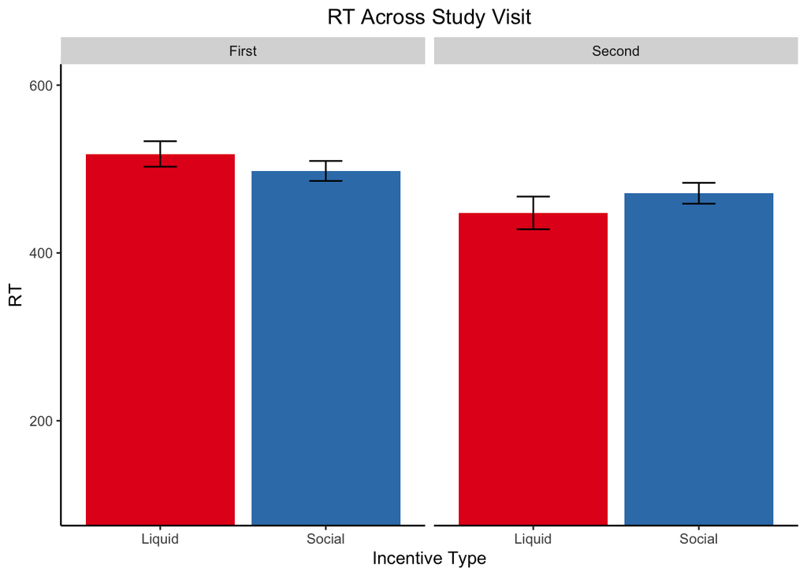

```r
#Summarizing RT by Session
RT.session.sum=summarySEwithin2(Session.RR, measurevar = "meanRT",
                        withinvars = "IncentiveType",betweenvars = "Visit",
                        idvar = "Subject")

p.Session.RT <- ggplot(RT.session.sum, aes(x=IncentiveType, y=meanRT, fill=IncentiveType)) +
  theme(plot.title = element_text(hjust = 0.5), panel.grid.major = element_blank(), panel.grid.minor = element_blank(), panel.background = element_blank(), axis.line = element_line(colour = "black"), legend.position = "none") +
  geom_bar(stat="identity", position=position_dodge()) +
  geom_errorbar(position=position_dodge(width=0.9), aes(ymin=meanRT-ci, ymax=meanRT+ci), width=.2) +
  coord_cartesian(ylim=c(100,600)) +
  xlab("Incentive Type") + ylab("RT") +ggtitle("RT Across Study Visit") +
  scale_fill_brewer(palette="Set1", name="Incentive Type") +
  facet_grid(.~Visit)
p.Session.RT
```

```r
reward.critRT <- group_by(Session.RR, IncentiveType,Visit,CriterionRT) %>%
  dplyr::summarise(meanCritRT = mean(CriterionRT))

  #Social Feedback MeanRR
 t.test(x = subset(Session.RR, IncentiveType=="Social" & Visit=="First")$meanRR,
       y = subset(Session.RR, IncentiveType=="Social" & Visit=="Second")$meanRR,
       paired = FALSE)
```

```
##
##  Welch Two Sample t-test
##
## data:  subset(Session.RR, IncentiveType == "Social" & Visit == "First")$meanRR and subset(Session.RR, IncentiveType == "Social" & Visit == "Second")$meanRR
## t = 4.1205, df = 209.83, p-value = 5.441e-05
## alternative hypothesis: true difference in means is not equal to 0
## 95 percent confidence interval:
##  0.03664669 0.10387618
## sample estimates:
## mean of x mean of y
## 0.6917892 0.6215278
```

```r
  #Liquid Feedback MeanRR
t.test(x = subset(Session.RR, IncentiveType=="Liquid" & Visit=="First")$meanRR,
       y = subset(Session.RR, IncentiveType=="Liquid" & Visit=="Second")$meanRR,
       paired = FALSE)
```

```
##
##  Welch Two Sample t-test
##
## data:  subset(Session.RR, IncentiveType == "Liquid" & Visit == "First")$meanRR and subset(Session.RR, IncentiveType == "Liquid" & Visit == "Second")$meanRR
## t = 2.7903, df = 265.31, p-value = 0.005648
## alternative hypothesis: true difference in means is not equal to 0
## 95 percent confidence interval:
##  0.01621623 0.09396117
## sample estimates:
## mean of x mean of y
## 0.6617063 0.6066176
```

```r
  #Session 1 MeanRR
t.test(x = subset(Session.RR, IncentiveType=="Social" & Visit=="First")$meanRR,
       y = subset(Session.RR, IncentiveType=="Liquid" & Visit=="First")$meanRR,
       paired = FALSE)
```

```
##
##  Welch Two Sample t-test
##
## data:  subset(Session.RR, IncentiveType == "Social" & Visit == "First")$meanRR and subset(Session.RR, IncentiveType == "Liquid" & Visit == "First")$meanRR
## t = 2.0619, df = 243.76, p-value = 0.04028
## alternative hypothesis: true difference in means is not equal to 0
## 95 percent confidence interval:
##  0.001344287 0.058821446
## sample estimates:
## mean of x mean of y
## 0.6917892 0.6617063
```

```r
  #Session 2 MeanRR
t.test(x = subset(Session.RR, IncentiveType=="Social" & Visit=="Second")$meanRR,
       y = subset(Session.RR, IncentiveType=="Liquid" & Visit=="Second")$meanRR,
       paired = FALSE)
```

```
##
##  Welch Two Sample t-test
##
## data:  subset(Session.RR, IncentiveType == "Social" & Visit == "Second")$meanRR and subset(Session.RR, IncentiveType == "Liquid" & Visit == "Second")$meanRR
## t = 0.68946, df = 276.98, p-value = 0.4911
## alternative hypothesis: true difference in means is not equal to 0
## 95 percent confidence interval:
##  -0.02766154  0.05748180
## sample estimates:
## mean of x mean of y
## 0.6215278 0.6066176
```

```r
#Social RT
t.test(x = subset(Session.RR, IncentiveType=="Social" & Visit=="First")$meanRT,
       y = subset(Session.RR, IncentiveType=="Social" & Visit=="Second")$meanRT,
       paired = FALSE)
```

```
##
##  Welch Two Sample t-test
##
## data:  subset(Session.RR, IncentiveType == "Social" & Visit == "First")$meanRT and subset(Session.RR, IncentiveType == "Social" & Visit == "Second")$meanRT
## t = 2.6908, df = 274.73, p-value = 0.007564
## alternative hypothesis: true difference in means is not equal to 0
## 95 percent confidence interval:
##   7.14094 46.07224
## sample estimates:
## mean of x mean of y
##  497.7410  471.1344
```

```r
  #Liquid RT
t.test(x = subset(Session.RR, IncentiveType=="Liquid" & Visit=="First")$meanRT,
       y = subset(Session.RR, IncentiveType=="Liquid" & Visit=="Second")$meanRT,
       paired = FALSE)
```

```
##
##  Welch Two Sample t-test
##
## data:  subset(Session.RR, IncentiveType == "Liquid" & Visit == "First")$meanRT and subset(Session.RR, IncentiveType == "Liquid" & Visit == "Second")$meanRT
## t = 5.446, df = 276.59, p-value = 1.138e-07
## alternative hypothesis: true difference in means is not equal to 0
## 95 percent confidence interval:
##  44.87357 95.67968
## sample estimates:
## mean of x mean of y
##  517.9819  447.7053
```

```r
  #Session 1 RT
t.test(x = subset(Session.RR, IncentiveType=="Social" & Visit=="First")$meanRT,
       y = subset(Session.RR, IncentiveType=="Liquid" & Visit=="First")$meanRT,
       paired = FALSE)
```

```
##
##  Welch Two Sample t-test
##
## data:  subset(Session.RR, IncentiveType == "Social" & Visit == "First")$meanRT and subset(Session.RR, IncentiveType == "Liquid" & Visit == "First")$meanRT
## t = -1.8388, df = 256.02, p-value = 0.0671
## alternative hypothesis: true difference in means is not equal to 0
## 95 percent confidence interval:
##  -41.917546   1.435782
## sample estimates:
## mean of x mean of y
##  497.7410  517.9819
```

```r
  #Session 2 RT
t.test(x = subset(Session.RR, IncentiveType=="Social" & Visit=="Second")$meanRT,
       y = subset(Session.RR, IncentiveType=="Liquid" & Visit=="Second")$meanRT,
       paired = FALSE)
```

```
##
##  Welch Two Sample t-test
##
## data:  subset(Session.RR, IncentiveType == "Social" & Visit == "Second")$meanRT and subset(Session.RR, IncentiveType == "Liquid" & Visit == "Second")$meanRT
## t = 1.9584, df = 263.62, p-value = 0.05124
## alternative hypothesis: true difference in means is not equal to 0
## 95 percent confidence interval:
##  -0.1271204 46.9854304
## sample estimates:
## mean of x mean of y
##  471.1344  447.7053
```

```r
  #Social CritRT
t.test(x = subset(reward.critRT, IncentiveType=="Social" & Visit=="First")$CriterionRT,
       y = subset(reward.critRT, IncentiveType=="Social" & Visit=="Second")$CriterionRT,
       paired = FALSE)
```

```
##
##  Welch Two Sample t-test
##
## data:  subset(reward.critRT, IncentiveType == "Social" & Visit == "First")$CriterionRT and subset(reward.critRT, IncentiveType == "Social" & Visit == "Second")$CriterionRT
## t = 1.3627, df = 26.417, p-value = 0.1845
## alternative hypothesis: true difference in means is not equal to 0
## 95 percent confidence interval:
##  -22.41495 110.78470
## sample estimates:
## mean of x mean of y
##  566.4706  522.2857
```

```r
  #Liquid CritRT
t.test(x = subset(reward.critRT, IncentiveType=="Liquid" & Visit=="First")$CriterionRT,
       y = subset(reward.critRT, IncentiveType=="Liquid" & Visit=="Second")$CriterionRT,
       paired = FALSE)
```

```
##
##  Welch Two Sample t-test
##
## data:  subset(reward.critRT, IncentiveType == "Liquid" & Visit == "First")$CriterionRT and subset(reward.critRT, IncentiveType == "Liquid" & Visit == "Second")$CriterionRT
## t = 3.8378, df = 28.231, p-value = 0.0006414
## alternative hypothesis: true difference in means is not equal to 0
## 95 percent confidence interval:
##   53.6677 176.4415
## sample estimates:
## mean of x mean of y
##  610.6429  495.5882
```

```r
  #Session 1 CritRT
t.test(x = subset(reward.critRT, IncentiveType=="Social" & Visit=="First")$CriterionRT,
       y = subset(reward.critRT, IncentiveType=="Liquid" & Visit=="First")$CriterionRT,
       paired = FALSE)
```

```
##
##  Welch Two Sample t-test
##
## data:  subset(reward.critRT, IncentiveType == "Social" & Visit == "First")$CriterionRT and subset(reward.critRT, IncentiveType == "Liquid" & Visit == "First")$CriterionRT
## t = -1.478, df = 28.17, p-value = 0.1505
## alternative hypothesis: true difference in means is not equal to 0
## 95 percent confidence interval:
##  -105.37673   17.03219
## sample estimates:
## mean of x mean of y
##  566.4706  610.6429
```

```r
  #Session 2 CritRT
t.test(x = subset(reward.critRT, IncentiveType=="Social" & Visit=="Second")$CriterionRT,
       y = subset(reward.critRT, IncentiveType=="Liquid" & Visit=="Second")$CriterionRT,
       paired = FALSE)
```

```
##
##  Welch Two Sample t-test
##
## data:  subset(reward.critRT, IncentiveType == "Social" & Visit == "Second")$CriterionRT and subset(reward.critRT, IncentiveType == "Liquid" & Visit == "Second")$CriterionRT
## t = 0.82121, df = 26.512, p-value = 0.4189
## alternative hypothesis: true difference in means is not equal to 0
## 95 percent confidence interval:
##  -40.06514  93.46010
## sample estimates:
## mean of x mean of y
##  522.2857  495.5882
```

### Self-Report Data

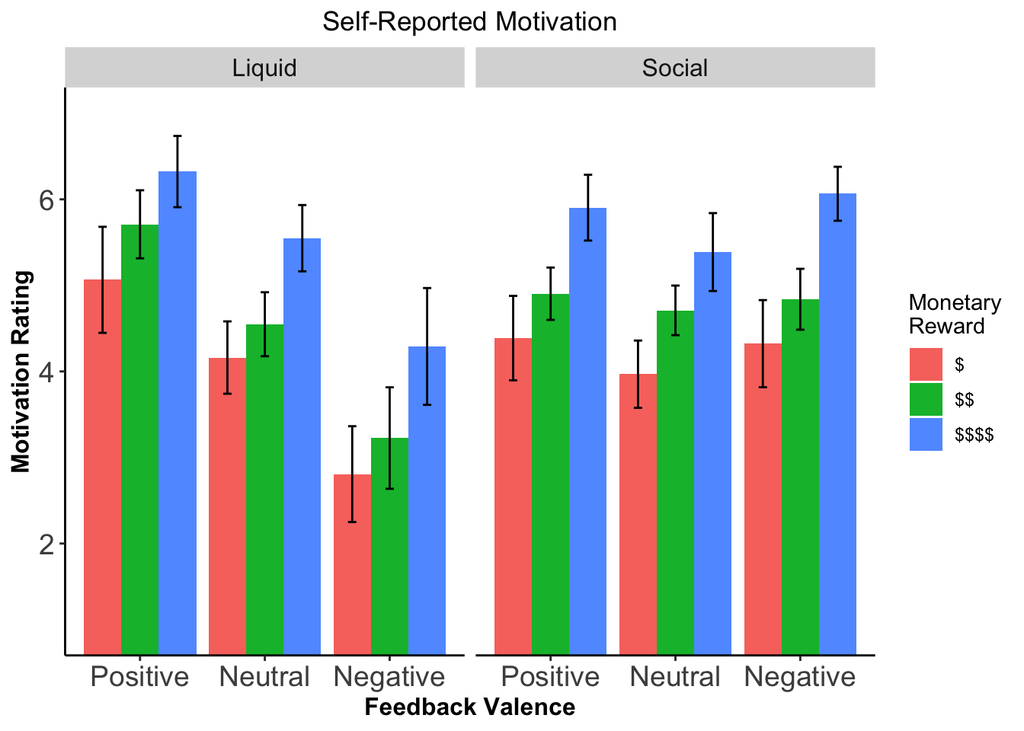

```r
# Import Self-Report Data
data.path.selfreport <- "https://raw.githubusercontent.com/jlcrawford/SocFeedback/master/Experiment1/Data/SFLF_SelfReport.csv"
data.post.task <- read.csv(data.path.selfreport, header = TRUE)

#Motivation Ratings
#Social Feedback
data.motivation.sf<-data.post.task %>%
  select(Subject,
         Positive_1=pos1_motive, Positive_2=pos2_motive, Positive_4=pos4_motive,
         Neutral_1=soc_neut1_motive, Neutral_2=soc_neut2_motive, Neutral_4=soc_neut4_motive,
         Negative_1=neg1_motive, Negative_2=neg2_motive, Negative_4=neg4_motive) %>%
  gather(key = condition, value = rating, Positive_1:Negative_4, factor_key = TRUE) %>%
  separate(col = condition, into=c("Valence","moneyreward"), sep = "_") %>%
  mutate(IncentiveType = "Social",
         rewCode = factor(moneyreward, levels = c(1,2,4), labels=c(-1,0,1)),
         money=factor(moneyreward, levels=c(1,2,4), labels=c("$","$$","$$$$")),
         valCode = factor(Valence, levels=c("Positive","Neutral","Negative"), labels=c(1,0,-1)),
         incentiveCode = factor(IncentiveType, levels=c("Social","Liquid"), labels=c(0,1)))
data.motivation.sf$rewCode <- as.numeric(levels(data.motivation.sf$rewCode)[data.motivation.sf$rewCode])
data.motivation.sf$valCode <- as.numeric(levels(data.motivation.sf$valCode)[data.motivation.sf$valCode])
data.motivation.sf$incentiveCode <- as.numeric(levels(data.motivation.sf$incentiveCode)[data.motivation.sf$incentiveCode])

#Liquid Feedback
data.motivation.lf<-data.post.task %>%
  select(Subject,
         Juice_1=juice1_motive, Juice_2=juice2_motive, Juice_4=juice4_motive,
         Neutral_1=neut1_motive, Neutral_2=neut2_motive, Neutral_4=neut4_motive,
         Saltwater_1=salt1_motive, Saltwater_2=salt2_motive, Saltwater_4=salt4_motive) %>%
  gather(key = condition, value = rating, Juice_1:Saltwater_4, factor_key = TRUE) %>%
  separate(col = condition, into=c("Valence","moneyreward"), sep = "_") %>%
  mutate(IncentiveType = "Liquid",
         Valence = factor(Valence, levels = c("Juice","Neutral","Saltwater"), labels = c("Positive","Neutral","Negative")),
         rewCode = factor(moneyreward, levels = c(1,2,4), labels=c(-1,0,1)),
         money=factor(moneyreward, levels=c(1,2,4), labels=c("$","$$","$$$$")),
         valCode = factor(Valence, levels=c("Positive","Neutral","Negative"), labels=c(1,0,-1)),
         incentiveCode = factor(IncentiveType, levels=c("Social","Liquid"), labels=c(0,1)))
data.motivation.lf$rewCode <- as.numeric(levels(data.motivation.lf$rewCode)[data.motivation.lf$rewCode])
data.motivation.lf$valCode <- as.numeric(levels(data.motivation.lf$valCode)[data.motivation.lf$valCode])
data.motivation.lf$incentiveCode <- as.numeric(levels(data.motivation.lf$incentiveCode)[data.motivation.lf$incentiveCode])

#Merging Social + Liquid Feedback Dataframes
data.motivation.sf.lf <- rbind(data.motivation.lf, data.motivation.sf)

data.motivation.sf.lf.sum<-summarySEwithin2(data = data.motivation.sf.lf, measurevar = "rating",
                                 withinvars = c("Valence","money","IncentiveType"),
                                 idvar = "Subject")

#Plotting the Post-Task Self-Reported Motivation Ratings
p.motivation.sf.lf<-ggplot(data = data.motivation.sf.lf.sum, aes(x = Valence, y = rating, fill = money)) +
  geom_bar(position=position_dodge(), stat = "identity") +
  coord_cartesian(ylim = c(1,7)) +
  geom_errorbar(position=position_dodge(.9),
                mapping = aes(ymin=rating-ci, ymax=rating+ci), width=.2) +
  xlab("Feedback Valence") + ylab("Motivation Rating") + ggtitle("Self-Reported Motivation") +
  scale_fill_discrete(name="Monetary\nReward") +
  theme(plot.title = element_text(hjust = 0.5), panel.grid.major = element_blank(), panel.grid.minor = element_blank(), panel.background = element_blank(), axis.line = element_line(colour = "black"),
    axis.title=element_text(size=12,face = "bold"),
    axis.text=element_text(size=14),
    legend.position="right",
    strip.text.x = element_text(size = 12)) +
  facet_grid(.~IncentiveType)
p.motivation.sf.lf
```

```r
#Summary of Motivation Ratings
data.motivation.sf.lf.sum$Valence <- factor(data.motivation.sf.lf.sum$Valence, levels = c("Positive","Neutral","Negative"))
data.motivation.sf.lf.sum$money <-  factor(data.motivation.sf.lf.sum$money, levels = c("$","$$","$$$$"), labels = c("Low","Medium","High"))
mot.tab.E1 <- data.motivation.sf.lf.sum %>% select(Valence, money, IncentiveType, rating, sd) %>%
  pivot_wider(names_from = "IncentiveType", values_from = c("rating","sd")) %>%
  select(Valence, money, rating_Liquid, sd_Liquid, rating_Social, sd_Social) %>%
  kable(., format = "html", digits = 3, booktabs = T,
        col.names = c("Feedback Valence", "Monetary Reward", rep(c("Mean","SD"), times = 2)),
        caption = "Post-Task Motivation Ratings") %>%
  kable_styling(full_width = F) %>%
  add_header_above(c(" " = 2, "Liquid" = 2, "Social" = 2)) %>%
  pack_rows("Negative", 1, 3) %>%
  pack_rows("Neutral", 4, 6) %>%
  pack_rows("Positive", 7, 9)
mot.tab.E1
```

Post-Task Motivation Ratings

| Feedback Valence | Monetary Reward | Liquid Mean | Liquid SD | Social Mean | Social SD |
| --- | --- | --- | --- | --- | --- |
| **Negative** |  |  |  |  |  |
| Negative | Low | 2.806 | 1.518 | 4.323 | 1.380 |
| Negative | Medium | 3.226 | 1.608 | 4.839 | 0.965 |
| Negative | High | 4.290 | 1.851 | 6.065 | 0.855 |
| **Neutral** |  |  |  |  |  |
| Neutral | Low | 4.161 | 1.146 | 3.968 | 1.066 |
| Neutral | Medium | 4.548 | 1.014 | 4.710 | 0.785 |
| Neutral | High | 5.548 | 1.050 | 5.387 | 1.234 |
| **Positive** |  |  |  |  |  |
| Positive | Low | 5.065 | 1.680 | 4.387 | 1.338 |
| Positive | Medium | 5.710 | 1.078 | 4.903 | 0.829 |
| Positive | High | 6.323 | 1.129 | 5.903 | 1.043 |

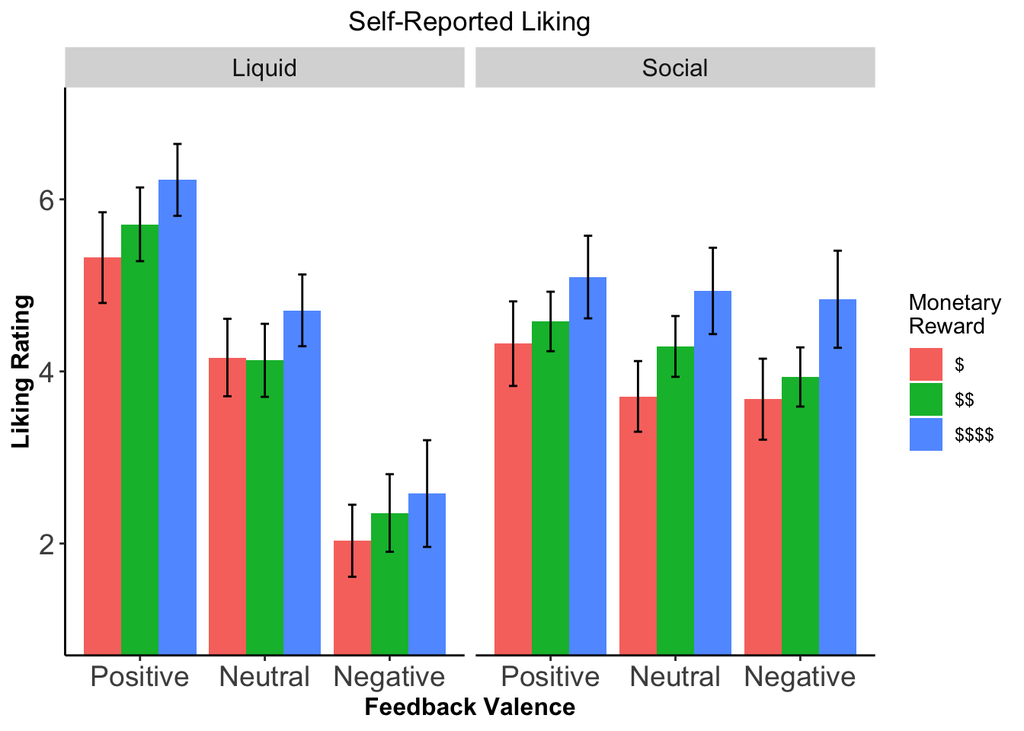

```r
#Omnibus ANOVA (Incentive Type x Valence x Monetary Reward)
anova.motive.E1<-ezANOVA(data = data.motivation.sf.lf, dv = rating, wid = .(Subject), within = c("Valence","IncentiveType","money"))

#Social Feedback ANOVA (Valence x Monetary Reward)
social.anova.motive.E1<-ezANOVA((data = data.motivation.sf.lf %>% filter(IncentiveType == "Social")), dv = rating, wid = .(Subject), within = c("Valence","money"))

#Liquid Feedback ANOVA (Valence x Monetary Reward)
liquid.anova.motive.E1<-ezANOVA((data = data.motivation.sf.lf %>% filter(IncentiveType == "Liquid")), dv = rating, wid = .(Subject), within = c("Valence","money"))

#Liking Ratings
#Social Feedback
data.liking.sf<-data.post.task %>%
  select(Subject,
         Positive_1=pos1_like, Positive_2=pos2_like, Positive_4=pos4_like,
         Neutral_1=soc_neut1_like, Neutral_2=soc_neut2_like, Neutral_4=soc_neut4_like,
         Negative_1=neg1_like, Negative_2=neg2_like, Negative_4=neg4_like) %>%
  gather(key = condition, value = rating, Positive_1:Negative_4, factor_key = TRUE) %>%
  separate(col = condition, into=c("Valence","moneyreward"), sep = "_") %>%
  mutate(IncentiveType = "Social",
         rewCode = factor(moneyreward, levels = c(1,2,4), labels=c(-1,0,1)),
         money=factor(moneyreward, levels=c(1,2,4), labels=c("$","$$","$$$$")),
         valCode = factor(Valence, levels=c("Positive","Neutral","Negative"), labels=c(1,0,-1)),
         incentiveCode = factor(IncentiveType, levels=c("Social","Liquid"), labels=c(0,1)))
data.liking.sf$rewCode <- as.numeric(levels(data.liking.sf$rewCode)[data.liking.sf$rewCode])
data.liking.sf$valCode <- as.numeric(levels(data.liking.sf$valCode)[data.liking.sf$valCode])
data.liking.sf$incentiveCode <- as.numeric(levels(data.liking.sf$incentiveCode)[data.liking.sf$incentiveCode])

#Liquid Feedback
data.liking.lf<-data.post.task %>%
  select(Subject,
         Juice_1=juice1_like, Juice_2=juice2_like, Juice_4=juice4_like,
         Neutral_1=neut1_like, Neutral_2=neut2_like, Neutral_4=neut4_like,
         Saltwater_1=salt1_like, Saltwater_2=salt2_like, Saltwater_4=salt4_like) %>%
  gather(key = condition, value = rating, Juice_1:Saltwater_4, factor_key = TRUE) %>%
  separate(col = condition, into=c("Valence","moneyreward"), sep = "_") %>%
  mutate(IncentiveType = "Liquid",
         Valence = factor(Valence, levels = c("Juice","Neutral","Saltwater"), labels = c("Positive","Neutral","Negative")),
         rewCode = factor(moneyreward, levels = c(1,2,4), labels=c(-1,0,1)),
         money=factor(moneyreward, levels=c(1,2,4), labels=c("$","$$","$$$$")),
         valCode = factor(Valence, levels=c("Positive","Neutral","Negative"), labels=c(1,0,-1)),
         incentiveCode = factor(IncentiveType, levels=c("Social","Liquid"), labels=c(0,1)))
data.liking.lf$rewCode <- as.numeric(levels(data.liking.lf$rewCode)[data.liking.lf$rewCode])
data.liking.lf$valCode <- as.numeric(levels(data.liking.lf$valCode)[data.liking.lf$valCode])
data.liking.lf$incentiveCode <- as.numeric(levels(data.liking.lf$incentiveCode)[data.liking.lf$incentiveCode])

#Merging Social + Liquid Feedback Dataframes
data.liking.sf.lf <- rbind(data.liking.lf, data.liking.sf)

data.liking.sf.lf.sum<-summarySEwithin2(data = data.liking.sf.lf, measurevar = "rating",
                                 withinvars = c("Valence","money","IncentiveType"),
                                 idvar = "Subject")

data.liking.sf.lf.sum$Valence <-factor(data.liking.sf.lf.sum$Valence, levels = c("Positive", "Neutral", "Negative"))
p.liking.sf.lf<-ggplot(data = data.liking.sf.lf.sum, aes(x = Valence, y = rating, fill = money)) +
  geom_bar(position=position_dodge(), stat = "identity") +
  coord_cartesian(ylim = c(1,7)) +
  geom_errorbar(position=position_dodge(.9),
                mapping = aes(ymin=rating-ci, ymax=rating+ci), width=.2) +
  xlab("Feedback Valence") + ylab("Liking Rating") + ggtitle("Self-Reported Liking") +
  scale_fill_discrete(name="Monetary\nReward") +
  theme(plot.title = element_text(hjust = 0.5), panel.grid.major = element_blank(), panel.grid.minor = element_blank(), panel.background = element_blank(), axis.line = element_line(colour = "black"),
    axis.title=element_text(size=12,face = "bold"),
    axis.text=element_text(size=14),
    legend.position="right",
    strip.text.x = element_text(size = 12)) +
  facet_grid(.~IncentiveType)
p.liking.sf.lf
```

```r
#Summary of Liking Ratings
data.liking.sf.lf.sum$Valence <- factor(data.liking.sf.lf.sum$Valence, levels = c("Positive","Neutral","Negative"))
data.liking.sf.lf.sum$money <-  factor(data.liking.sf.lf.sum$money, levels = c("$","$$","$$$$"), labels = c("Low","Medium","High"))
liking.tab.E1 <- data.liking.sf.lf.sum %>% select(Valence, money, IncentiveType, rating, sd) %>%
  pivot_wider(names_from = "IncentiveType", values_from = c("rating","sd")) %>%
  select(Valence, money, rating_Liquid, sd_Liquid, rating_Social, sd_Social) %>%
  kable(., format = "html", digits = 3, booktabs = T,
        col.names = c("Feedback Valence", "Monetary Reward", rep(c("Mean","SD"), times = 2)),
        caption = "Post-Task Liking Ratings") %>%
  kable_styling(full_width = F) %>%
  add_header_above(c(" " = 2, "Liquid" = 2, "Social" = 2)) %>%
  pack_rows("Negative", 1, 3) %>%
  pack_rows("Neutral", 4, 6) %>%
  pack_rows("Positive", 7, 9)
liking.tab.E1
```

Post-Task Liking Ratings

| Feedback Valence | Monetary Reward | Liquid Mean | Liquid SD | Social Mean | Social SD |
| --- | --- | --- | --- | --- | --- |
| **Negative** |  |  |  |  |  |
| Negative | Low | 2.032 | 1.141 | 3.677 | 1.283 |
| Negative | Medium | 2.355 | 1.229 | 3.935 | 0.938 |
| Negative | High | 2.581 | 1.690 | 4.839 | 1.538 |
| **Neutral** |  |  |  |  |  |
| Neutral | Low | 4.161 | 1.226 | 3.710 | 1.119 |
| Neutral | Medium | 4.129 | 1.157 | 4.290 | 0.963 |
| Neutral | High | 4.710 | 1.137 | 4.935 | 1.368 |
| **Positive** |  |  |  |  |  |
| Positive | Low | 5.323 | 1.437 | 4.323 | 1.340 |
| Positive | Medium | 5.710 | 1.167 | 4.581 | 0.943 |
| Positive | High | 6.226 | 1.139 | 5.097 | 1.309 |

```r
#Omnibus ANOVA (Incentive Type x Valence x Monetary Reward)
anova.liking.E1<-ezANOVA(data = data.liking.sf.lf, dv = rating, wid = .(Subject), within = c("Valence","IncentiveType","money"))

#Social Feedback ANOVA (Valence x Monetary Reward)
social.anova.liking.E1<-ezANOVA((data = data.liking.sf.lf %>% filter(IncentiveType == "Social")), dv = rating, wid = .(Subject), within = c("Valence","money"))

#Liquid Feedback ANOVA (Valence x Monetary Reward)
liquid.anova.liking.E1<-ezANOVA((data = data.liking.sf.lf %>% filter(IncentiveType == "Liquid")), dv = rating, wid = .(Subject), within = c("Valence","money"))

#BISBAS
BISBAS <- data.post.task %>% select(Subject, starts_with("bisbas")) %>% select(-"bisbas_complete") %>%
  gather(key = item, value = value, -starts_with("Subject")) %>%
  separate(item, c(NA, "trait"), sep = "_") %>%
  separate(trait, sep = -1, into = c("trait", NA)) %>%
  group_by(Subject, trait) %>%
  summarise(sum = sum(value, na.rm = T)) %>%
  ungroup() %>%
  spread(key= trait, value = sum) %>%
  rename("BAS_Drive" = d,
         "BAS_Fun" = f,
         "BAS_Reward" = rr,
         "BIS" = bis) %>%
  mutate(BAS_total = (BAS_Drive + BAS_Fun + BAS_Reward))
BISBAS.means <- BISBAS %>%
  dplyr::summarise("BAS Reward" = mean(BAS_Reward), "BAS Reward (sd)" = sd(BAS_Reward), "BAS Fun" = mean(BAS_Fun), "BAS Fun (sd)" = sd(BAS_Fun),
                   "BAS Drive" = mean(BAS_Reward), "BAS Drive (sd)" = sd(BAS_Drive), "BIS" = mean(BIS), "BIS (sd)" = sd(BIS)) %>%
  kable(format = "html", caption = "BIS/BAS Means") %>%
  kable_styling(full_width = F)
BISBAS.means
```

BIS/BAS Means

| BAS Reward | BAS Reward (sd) | BAS Fun | BAS Fun (sd) | BAS Drive | BAS Drive (sd) | BIS | BIS (sd) |
| --- | --- | --- | --- | --- | --- | --- | --- |
| 22.41935 | 2.655487 | 14.96774 | 3.737057 | 22.41935 | 3.180924 | 25.3871 | NA |

```r
#DARS
DARS <- data.post.task %>% select(Subject, starts_with("dars")) %>% select(-"dars_complete") %>% select(-contains("_desc")) %>%
  gather(key = item, value = value, -starts_with("Subject")) %>%
  separate(item, c(NA, "item", NA), sep = "_") %>%
  group_by(Subject, item) %>%
  summarise(sum = sum(value, na.rm = T)) %>%
  ungroup() %>%
  spread(key= item, value = sum) %>%
   rename("DARS_Food" = food,
         "DARS_Hobby" = hobby,
         "DARS_Sensory" = sensory,
         "DARS_Social" = social) %>%
  mutate(DARS_total = (DARS_Food + DARS_Hobby + DARS_Sensory + DARS_Social))
DARS.means <- DARS %>%
  dplyr::summarise("DARS Hobby" = mean(DARS_Hobby), "DARS Hobby (sd)" = sd(DARS_Hobby), "DARS Food" = mean(DARS_Food), "DARS Food (sd)" = sd(DARS_Food),
                   "DARS Social" = mean(DARS_Social), "DARS Social (sd)" = sd(DARS_Social), "DARS Sensory" = mean(DARS_Sensory), "DARS Sensory (sd)" = sd(DARS_Sensory)) %>%
  kable(format = "html", caption = "DARS Means") %>%
    kable_styling(full_width = F)
DARS.means
```

DARS Means

| DARS Hobby | DARS Hobby (sd) | DARS Food | DARS Food (sd) | DARS Social | DARS Social (sd) | DARS Sensory | DARS Sensory (sd) |
| --- | --- | --- | --- | --- | --- | --- | --- |
| 15.29032 | 1.465004 | 14.06452 | 2.06455 | 13.16129 | 2.23751 | 15.74194 | 4.289271 |

# Experiment II - Within-Subject Manipulation of both social (static stim) and liquid feedback

```r
#import data paths from github
data.path <- "https://raw.githubusercontent.com/jlcrawford/SocFeedback/master/Experiment2/Data/Data_Reward.csv"
baseline.path<-"https://raw.githubusercontent.com/jlcrawford/SocFeedback/master/Experiment2/Data/Data_Baseline.csv"
indiv.path <- "https://raw.githubusercontent.com/jlcrawford/SocFeedback/master/Experiment2/Data/Data_Indiv_Composite.csv"
ratings.liq.path <- "https://raw.githubusercontent.com/jlcrawford/SocFeedback/master/Experiment2/Data/Data_Ratings_Liquid.csv"
ratings.soc.path <- "https://raw.githubusercontent.com/jlcrawford/SocFeedback/master/Experiment2/Data/Data_Ratings_Social.csv"
```

## Formatting the Data

```r
# Reading the data
data<-read.csv(data.path,header=TRUE, sep = ",") %>% select(-X)
data.base<-read.csv(baseline.path, header = TRUE, sep  = ",") %>% select(-X)
sub.exclude <-c(1,4,6,18,28,37,44,65,86)
data <- data %>% filter(!subID %in% sub.exclude)

TrialTotal_df<-data.frame(rep(c(1:288),length(data$subID),dim(data)[1]))
names(TrialTotal_df)<-c("TrialTotal")

# Formatting the incentive data to include rewarded trials and error trials, as well as dummy coding
data <- data %>%
  mutate(subRewarded = (RT<critRT & ACC==1)*1, subError = (ACC==0 & RT>critRT)*1,
         moneynumber = factor(Reward, levels = c("Reward1","Reward2","Reward4"), labels = c(1,2,4)),
         moneyreward = factor(Reward, levels = c("Reward1","Reward2","Reward4"), labels = c("$","$$","$$$$")),
         rewCode = factor(Reward, levels=c("Reward1","Reward2","Reward4"), labels=c(-1,0,1)),
         Valence = factor(Valence, levels=c("appetitive","neutral","aversive"), labels=c("Positive","Neutral","Negative")),
         valCode = factor(Valence, levels=c("Positive","Neutral","Negative"), labels=c(1,0,-1)),
         IncentiveType = factor(IncentiveType, levels=c("face","liquid"), labels=c("Social","Liquid")),
         incentiveCode = factor(IncentiveType, levels=c("Social","Liquid"), labels=c(0,1)))
data$rewCode <- as.numeric(levels(data$rewCode)[data$rewCode])
data$valCode <- as.numeric(levels(data$valCode)[data$valCode])
data$incentiveCode <- as.numeric(levels(data$incentiveCode)[data$incentiveCode])
```

## Reward Rate Calculation

```r
# Group by face vs liquid
data.incentive.means = group_by(data, subID, IncentiveType) %>% filter(!is.na(subRewarded)) %>%
  dplyr::summarise(n=n(), meanRR = mean(subRewarded), meanACC = mean(ACC), meanErr = mean(subError))
data.incentive.RTmeans = group_by(data, subID, IncentiveType) %>% filter(!is.na(subRewarded) & ACC==1) %>%
  dplyr::summarise(n=n(), meanRT = mean(RT))

# Group by valence (appetive, neutral, aversive)
data.val.means = group_by(data, subID, Valence) %>% filter(!is.na(subRewarded)) %>%
  dplyr::summarise(n=n(), meanRR = mean(subRewarded), meanACC = mean(ACC), meanErr = mean(subError))
data.val.RTmeans = group_by(data, subID, Valence) %>% filter(!is.na(subRewarded) & ACC==1) %>%
  dplyr::summarise(n=n(), meanRT = mean(RT))

# Group by valence (appetitive, neutral, aversive) and incentive type (face, liquid)
data.val.inc.means = group_by(data, subID, Valence, IncentiveType) %>% filter(!is.na(subRewarded)) %>%
  dplyr::summarise(n=n(), meanRR = mean(subRewarded), meanACC = mean(ACC), meanErr = mean(subError))
data.val.inc.RTmeans = group_by(data, subID, Valence, IncentiveType) %>% filter(!is.na(subRewarded) & ACC==1) %>%
  dplyr::summarise(n=n(), meanRT = mean(RT))

# Group by monetary reward ($, $$, $$$)
data.money.inc.means = group_by(data, subID, moneyreward, IncentiveType) %>% filter(!is.na(subRewarded)) %>%
  dplyr::summarise(n=n(), meanRR = mean(subRewarded), meanACC = mean(ACC), meanErr = mean(subError))

data.val.inc.mon.means = group_by(data, subID, Valence,IncentiveType,moneyreward) %>% filter(!is.na(subRewarded)) %>%
  dplyr::summarise(n=n(), meanRR = mean(subRewarded, na.rm = T), sdRR = sd(subRewarded, na.rm = T), meanACC = mean(ACC, na.rm = T), sdACC = sd(ACC, na.rm = T), meanErr = mean(subError, na.rm = T), sdErr = sd(subError, na.rm = T))
data.val.inc.mon.RTmeans = group_by(data, subID, Valence,IncentiveType,moneyreward) %>% filter(!is.na(subRewarded) & ACC==1) %>%
  dplyr::summarise(n=n(), meanRT = mean(RT, na.rm = T), sdRR = sd(RT, na.rm = T))

data.val.inc.mon.means<-data.frame(data.val.inc.mon.means)
RR.sum.2<-summarySEwithin2(data = data.val.inc.mon.means, measurevar = "meanRR", withinvars = c("Valence","IncentiveType","moneyreward"), idvar = "subID")
RR.sum.2$Valence<-factor(x = RR.sum.2$Valence, levels=c("Positive","Neutral","Negative")) # change order of factors
RR.sum.2$IncentiveType<-factor(x = RR.sum.2$IncentiveType, levels=c("Liquid","Social"))

#Reward Rate Difference Across Social and Liquid Feedback
t.test(x = subset(data.incentive.means, IncentiveType=="Social")$meanRR,
       y = subset(data.incentive.means, IncentiveType=="Liquid")$meanRR,
       paired = TRUE)
```

```
##
##  Paired t-test
##
## data:  subset(data.incentive.means, IncentiveType == "Social")$meanRR and subset(data.incentive.means, IncentiveType == "Liquid")$meanRR
## t = 6.7446, df = 73, p-value = 3.089e-09
## alternative hypothesis: true difference in means is not equal to 0
## 95 percent confidence interval:
##  0.06128711 0.11269938
## sample estimates:
## mean of the differences
##              0.08699324
```

```r
S.mean.RR.2 = mean(subset(data.incentive.means, IncentiveType=="Social")$meanRR)
L.mean.RR.2 = mean(subset(data.incentive.means, IncentiveType=="Liquid")$meanRR)

#Accuracy Difference Across Social and Liquid Feedback
t.test(x = subset(data.incentive.means, IncentiveType=="Social")$meanACC,
       y = subset(data.incentive.means, IncentiveType=="Liquid")$meanACC,
       paired = TRUE)
```

```
##
##  Paired t-test
##
## data:  subset(data.incentive.means, IncentiveType == "Social")$meanACC and subset(data.incentive.means, IncentiveType == "Liquid")$meanACC
## t = 5.1809, df = 73, p-value = 1.888e-06
## alternative hypothesis: true difference in means is not equal to 0
## 95 percent confidence interval:
##  0.04027614 0.09063603
## sample estimates:
## mean of the differences
##              0.06545608
```

```r
S.mean.ACC.2 = mean(subset(data.incentive.means, IncentiveType=="Social")$meanACC)
L.mean.ACC.2 = mean(subset(data.incentive.means, IncentiveType=="Liquid")$meanACC)

#Error Rate Difference Across Social and Liquid Feedback
t.test(x = subset(data.incentive.means, IncentiveType=="Social")$meanErr,
       y = subset(data.incentive.means, IncentiveType=="Liquid")$meanErr,
       paired = TRUE)
```

```
##
##  Paired t-test
##
## data:  subset(data.incentive.means, IncentiveType == "Social")$meanErr and subset(data.incentive.means, IncentiveType == "Liquid")$meanErr
## t = -3.3918, df = 73, p-value = 0.001124
## alternative hypothesis: true difference in means is not equal to 0
## 95 percent confidence interval:
##  -0.019368051 -0.005031348
## sample estimates:
## mean of the differences
##              -0.0121997
```

```r
S.mean.Err.2 = mean(subset(data.incentive.means, IncentiveType=="Social")$meanErr)
L.mean.Err.2 = mean(subset(data.incentive.means, IncentiveType=="Liquid")$meanErr)
```

### Summary Table of Reward Rate, Accuracy, Error Rate, and RT

```r
#Summary Table of Rewrard Rate, Accuracy, Error Rate, and RT
RR.summary.2<-summarySEwithin2(data = data.val.inc.mon.means, measurevar = "meanRR", withinvars = c("Valence","IncentiveType","moneyreward"), idvar = "subID")
ACC.summary <-summarySEwithin2(data = data.val.inc.mon.means, measurevar = "meanACC", withinvars = c("Valence","IncentiveType","moneyreward"), idvar = "subID") %>%
  rename("ACC_mean" =  meanACC,
         "ACC_sd" = sd) %>%
  select(ACC_mean, ACC_sd)

Err.summary <- summarySEwithin2(data = data.val.inc.mon.means, measurevar = "meanErr", withinvars = c("Valence","IncentiveType","moneyreward"), idvar = "subID") %>%
   rename("Err_mean" = meanErr,
         "Err_sd" = sd) %>%
  select(Err_mean, Err_sd)

RT.summary <- summarySEwithin2(data = data.val.inc.mon.RTmeans, measurevar = "meanRT", withinvars = c("Valence","IncentiveType","moneyreward"), idvar = "subID") %>%
   rename("RT_mean" = meanRT,
         "RT_sd" = sd) %>%
  select(RT_mean, RT_sd)

summary.table.2 <- cbind(RR.summary.2,ACC.summary, Err.summary, RT.summary) %>%
  rename("RR_mean" = meanRR,
         "RR_sd" = sd) %>%
  select(-c("N","meanRRNormed","se","ci"))

###Summary Table: Reward Rate, Accuracy, Error Rate, RT
summary.table.2$moneyreward <- factor(summary.table.2$moneyreward, levels = c("$","$$","$$$$"), labels = c("Low","Medium","High"))
tab.RR.sum.2 <- summary.table.2 %>%
  pivot_wider(names_from = "IncentiveType", values_from = c("RR_mean","RR_sd","ACC_mean","ACC_sd","Err_mean","Err_sd",
                                                            "RT_mean","RT_sd")) %>%
  select(Valence, moneyreward, RR_mean_Liquid, RR_sd_Liquid, ACC_mean_Liquid, ACC_sd_Liquid, Err_mean_Liquid, Err_sd_Liquid, RT_mean_Liquid, RT_sd_Liquid,
         RR_mean_Social, RR_sd_Social, ACC_mean_Social, ACC_sd_Social, Err_mean_Social, Err_sd_Social, RT_mean_Social, RT_sd_Social)  %>%
  kable(., format = "html", digits = 3, booktabs = T,
        col.names = c("Feedback Valence", "Monetary Reward", rep(c("Mean","SD"), times = 8)),
        caption = "Task Performance Variables") %>%
  kable_styling(full_width = F) %>%
  add_header_above(c(" " = 2, "Reward Rate" = 2, "Accuracy" = 2, "Error Rate" = 2, "Reaction Time" = 2,
                   "Reward Rate" = 2, "Accuracy" = 2, "Error Rate" = 2, "Reaction Time" = 2)) %>%
  add_header_above(c(" " = 2, "Liquid" = 8, "Social" = 8)) %>%
  pack_rows("Negative", 1, 3) %>%
  pack_rows("Neutral", 4, 6) %>%
  pack_rows("Positive", 7, 9)
tab.RR.sum.2
```

Task Performance Variables

| Feedback Valence | Monetary Reward | Liquid Reward Rate Mean | Liquid Reward Rate SD | Liquid Accuracy Mean | Liquid Accuracy SD | Liquid Error Rate Mean | Liquid Error Rate SD | Liquid Reaction Time Mean | Liquid Reaction Time SD | Social Reward Rate Mean | Social Reward Rate SD | Social Accuracy Mean | Social Accuracy SD | Social Error Rate Mean | Social Error Rate SD | Social Reaction Time Mean | Social Reaction Time SD |
| --- | --- | --- | --- | --- | --- | --- | --- | --- | --- | --- | --- | --- | --- | --- | --- | --- | --- |
| **Negative** |  |  |  |  |  |  |  |  |  |  |  |  |  |  |  |  |  |
| Negative | Low | 0.511 | 0.238 | 0.690 | 0.242 | 0.053 | 0.078 | 613.402 | 138.251 | 0.711 | 0.102 | 0.865 | 0.090 | 0.030 | 0.034 | 548.123 | 46.697 |
| Negative | Medium | 0.535 | 0.197 | 0.735 | 0.208 | 0.043 | 0.055 | 611.458 | 105.986 | 0.712 | 0.091 | 0.877 | 0.071 | 0.028 | 0.035 | 551.252 | 49.291 |
| Negative | High | 0.641 | 0.162 | 0.797 | 0.136 | 0.037 | 0.039 | 567.344 | 95.681 | 0.760 | 0.089 | 0.883 | 0.076 | 0.019 | 0.027 | 531.422 | 44.855 |
| **Neutral** |  |  |  |  |  |  |  |  |  |  |  |  |  |  |  |  |  |
| Neutral | Low | 0.616 | 0.155 | 0.811 | 0.141 | 0.046 | 0.049 | 576.903 | 73.455 | 0.709 | 0.090 | 0.869 | 0.076 | 0.035 | 0.036 | 553.126 | 44.661 |
| Neutral | Medium | 0.637 | 0.126 | 0.839 | 0.102 | 0.035 | 0.040 | 576.463 | 72.821 | 0.701 | 0.086 | 0.875 | 0.078 | 0.030 | 0.036 | 554.327 | 41.506 |
| Neutral | High | 0.671 | 0.104 | 0.830 | 0.086 | 0.041 | 0.045 | 545.730 | 51.642 | 0.746 | 0.099 | 0.878 | 0.084 | 0.023 | 0.031 | 534.400 | 40.584 |
| **Positive** |  |  |  |  |  |  |  |  |  |  |  |  |  |  |  |  |  |
| Positive | Low | 0.657 | 0.114 | 0.840 | 0.074 | 0.043 | 0.043 | 560.670 | 53.857 | 0.702 | 0.110 | 0.879 | 0.086 | 0.024 | 0.036 | 557.400 | 49.939 |
| Positive | Medium | 0.681 | 0.107 | 0.861 | 0.072 | 0.038 | 0.036 | 561.586 | 58.146 | 0.692 | 0.095 | 0.866 | 0.088 | 0.030 | 0.031 | 558.283 | 50.756 |
| Positive | High | 0.728 | 0.097 | 0.877 | 0.070 | 0.022 | 0.027 | 539.483 | 52.450 | 0.728 | 0.101 | 0.875 | 0.077 | 0.027 | 0.038 | 540.874 | 49.301 |

### Figure 4: Incentive Integration Effects across Social & Liquid Feedback (Experiment II)

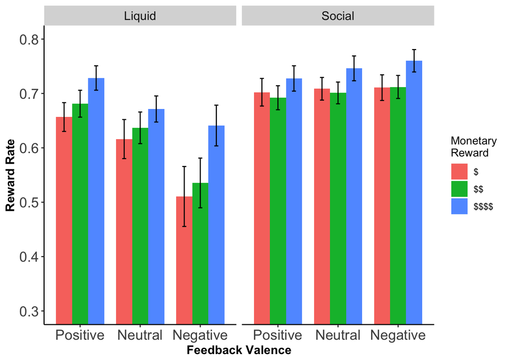

```r
#Plotting reward rate across Social + Liquid feedback by Valence and Monetary Reward (Figure 4)
p.RR.Exp2<-ggplot(RR.sum.2, aes(x=Valence, y=meanRR, fill=moneyreward)) +
  geom_bar(position=position_dodge(width=0.8), stat="identity", width=0.8) +
  geom_errorbar(position=position_dodge(width=0.8), aes(ymin=meanRR-ci, ymax=meanRR+ci), width=.2) +
  labs(x="Feedback Valence",y="Reward Rate") +
  scale_x_discrete(labels=c("Positive","Neutral","Negative")) +
  scale_fill_discrete(name="Monetary\nReward") +
  coord_cartesian(ylim=c(.3,.80)) +
    theme(plot.title = element_text(hjust = 0.5), panel.grid.major = element_blank(), panel.grid.minor = element_blank(), panel.background = element_blank(), axis.line = element_line(colour = "black"),
    axis.title=element_text(size=12,face = "bold"),
    axis.text=element_text(size=14),
    legend.position="right",
    strip.text.x = element_text(size = 12)) +
  facet_grid(.~IncentiveType)
p.RR.Exp2
```

### ANOVA Tables: Feedback Valence x Incentive Type x Monetary Reward (Experiment II)

```r
#Omnibus ANOVA (Incentive Type x Valence x Monetary Reward)
omnibus.anova.E2<-ezANOVA(data = data.val.inc.mon.means, dv = meanRR, wid = .(subID), within = c("Valence","IncentiveType","moneyreward"))
d.anova.E2 <- omnibus.anova.E2$ANOVA %>%
  mutate(Effect = factor(Effect, levels = c("Valence","IncentiveType","moneyreward","Valence:IncentiveType",
                                            "Valence:moneyreward","IncentiveType:moneyreward","Valence:IncentiveType:moneyreward"),
                         labels = c("Feedback Valence","Incentive Type","Monetary Reward","Feedback Valence x Incentive Type","Feedback Valence x Monetary Reward",
                                    "Incentive Type x Monetary Reward", "Feedback Valence x Incentive Type x Monetary Reward"))) %>%
  rename("Generalized Eta Squared" = ges)
tab.omnibus.E2 <- kable(d.anova.E2, format = "html", digits = 3, caption = "Monetary Reward x Feedback Valence x Incentive Session -- Experiment II") %>%
  kable_styling(bootstrap_options = "striped", full_width = F)
tab.omnibus.E2
```

Monetary Reward x Feedback Valence x Incentive Session – Experiment II

Effect

DFn

DFd

F

p

p<.05

Generalized Eta Squared

Feedback Valence

2

146

12.399

0.000

0.019

Incentive Type

1

73

45.489

0.000

0.069

Monetary Reward

2

146

34.715

0.000

0.028

Feedback Valence x Incentive Type

2

146

24.328

0.000

0.035

Feedback Valence x Monetary Reward

4

292

3.484

0.008

0.003

Incentive Type x Monetary Reward

2

146

5.185

0.007

0.004

Feedback Valence x Incentive Type x Monetary Reward

4

292

1.717

0.146

0.002

```r
#Social Feedback ANOVA (Valence x Monetary Reward)
social.anova.E2<-ezANOVA((data = data.val.inc.mon.means %>% filter(IncentiveType== "Social")), dv = meanRR, wid = .(subID), within = c("Valence","moneyreward"))
d.soc.anova.E2 <- social.anova.E2$ANOVA %>%
  mutate(Effect = factor(Effect, levels = c("Valence","moneyreward","Valence:moneyreward"),
                         labels = c("Feedback Valence","Monetary Reward","Feedback Valence x Monetary Reward"))) %>%
  rename("Generalized Eta Squared" = ges)
tab.soc.E2 <- kable(d.soc.anova.E2, digits = 3, caption = "Social Feedback ANOVA (Feedback Valence x Monetary Reward)") %>%
  kable_styling(bootstrap_options = "striped", full_width = F)
tab.soc.E2
```

Social Feedback ANOVA (Feedback Valence x Monetary Reward)

Effect

DFn

DFd

F

p

p<.05

Generalized Eta Squared

Feedback Valence

2

146

3.463

0.034

0.004

Monetary Reward

2

146

16.200

0.000

0.022

Feedback Valence x Monetary Reward

4

292

0.493

0.741

0.001

```r
#Liquid Feedback ANOVA (Valence x Monetary Reward)
liquid.anova.E2<-ezANOVA((data = data.val.inc.mon.means %>% filter(IncentiveType== "Liquid")), dv = meanRR, wid = .(subID), within = c("Valence","moneyreward"))
d.liq.anova.E2 <-liquid.anova.E2$ANOVA %>%
  mutate(Effect = factor(Effect, levels = c("Valence","moneyreward","Valence:moneyreward"),
                         labels = c("Feedback Valence","Monetary Reward","Feedback Valence x Monetary Reward"))) %>%
  rename("Generalized Eta Squared" = ges)
tab.liq.E2 <- kable(d.liq.anova.E2, digits = 3, caption = "Liquid Feedback ANOVA (Feedback Valence x Monetary Reward)") %>%
  kable_styling(bootstrap_options = "striped", full_width = F)
tab.liq.E2
```

Liquid Feedback ANOVA (Feedback Valence x Monetary Reward)

Effect

DFn

DFd

F

p

p<.05

Generalized Eta Squared

Feedback Valence

2

146

20.423

0.000

0.072

Monetary Reward

2

146

22.530

0.000

0.036

Feedback Valence x Monetary Reward

4

292

3.749

0.005

0.006

## Supplemental Material

### Reward Rate Across Incentive Type

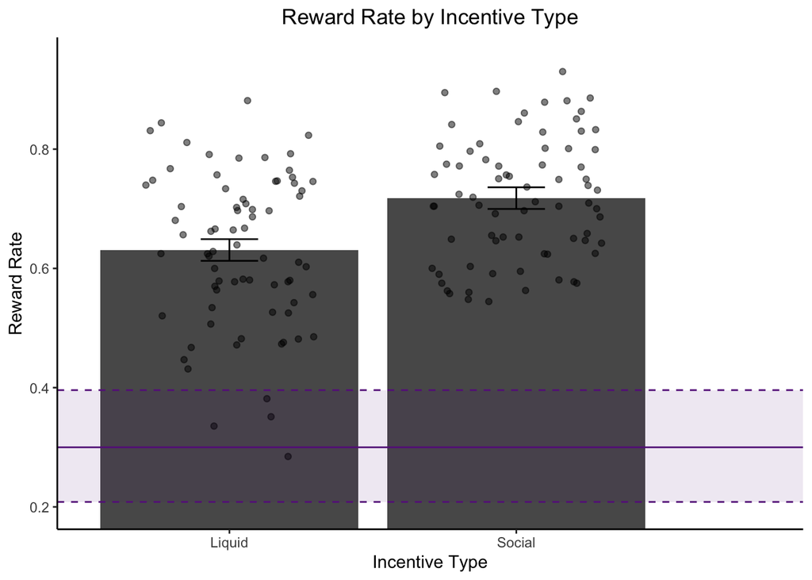

```r
#Plotting Mean Reward Rate Across both incentive modalities (liquid, social)
RR.session.sum.2 <- summarySEwithin2(data = data.incentive.means, idvar = "subID", measurevar = "meanRR", withinvars = "IncentiveType")
RR.session.sum.2$IncentiveType <- factor(RR.session.sum.2$IncentiveType, levels = c("Liquid","Social"))
p.Session.RR.ind.2 <- ggplot(data = RR.session.sum.2, aes(x=IncentiveType, y=meanRR)) +
           geom_bar(stat="identity", position=position_dodge()) +
  geom_errorbar(data = RR.session.sum.2, position=position_dodge(width=0.9), aes(ymin=meanRR-ci, ymax=meanRR+ci), width=.2) +
  geom_point(data = data.incentive.means, aes(x=IncentiveType, y=meanRR),
             stat="identity", position=position_jitter(w=.3), alpha=0.5) +
  geom_hline(yintercept = .3, color="darkorchid4") +
  geom_hline(yintercept = reward_crit_low, color="darkorchid4", linetype="dashed") +
  geom_hline(yintercept = reward_crit_high, color="darkorchid4", linetype="dashed") +
  geom_rect(mapping = aes(xmin=.4,xmax=3,ymin=reward_crit_low,ymax=reward_crit_high), fill="darkorchid4", alpha=0.05) +
   theme(plot.title = element_text(hjust = 0.5), panel.grid.major = element_blank(), panel.grid.minor = element_blank(), panel.background = element_blank(), axis.line = element_line(colour = "black")) +
  coord_cartesian(ylim=c(.2,.95)) +
  xlab("Incentive Type") + ylab("Reward Rate") + ggtitle("Reward Rate by Incentive Type")
p.Session.RR.ind.2
```

### Post-Task Ratings

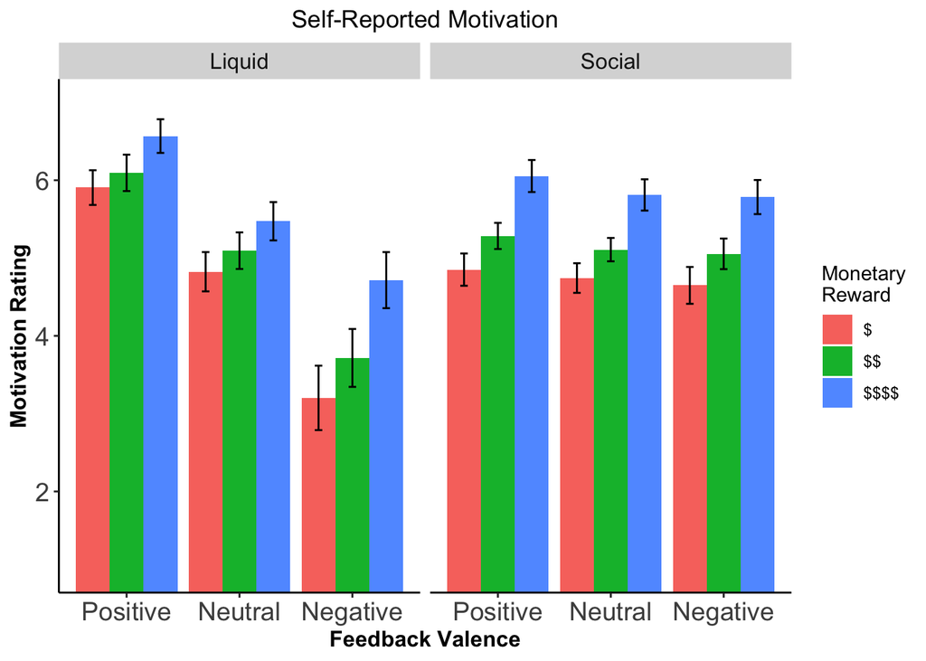

```r
# Self-Report Ratings for Liquid and Social Incentives (Post-Task)
# Liquid Feedback
data.ratings.liquid<-read.csv(file = ratings.liq.path, sep=",")
data.ratings.liquid <- data.ratings.liquid %>% filter(!subID %in% sub.exclude)

#Social Feedback
data.ratings.social<-read.csv(file = ratings.soc.path, sep=",")
data.ratings.social <- data.ratings.social %>% filter(!subID %in% sub.exclude)

#Motivation Ratings
# Liquid motivation ratings
data.mot.lf<-select(data.ratings.liquid, subID,
                 Juice_1Motivation, Juice_2Motivation, Juice_4Motivation,
                 Neutral_1Motivation, Neutral_2Motivation, Neutral_4Motivation,
                 Salt_1Motivation, Salt_2Motivation, Salt_4Motivation) %>%
  pivot_longer(names_to = "motivation", values_to = "rating", -subID) %>%
  separate(motivation, into = c("Valence","misc"), sep = "_") %>%
  separate(misc, into = c("moneyreward", NA), sep = 1) %>%
  mutate(IncentiveType = "Liquid",
         rewCode = factor(moneyreward, levels = c(1,2,4), labels=c(-1,0,1)),
         money=factor(moneyreward, levels=c(1,2,4), labels=c("$","$$","$$$$")),
         Valence=factor(Valence, levels = c("Juice","Neutral","Salt"), labels = c("Positive","Neutral","Negative")),
         valCode = factor(Valence, levels=c("Positive","Neutral","Negative"), labels=c(1,0,-1)),
         incentiveCode = factor(IncentiveType, levels=c("Social","Liquid"), labels=c(0,1)))
data.mot.lf$rewCode <- as.numeric(levels(data.mot.lf$rewCode)[data.mot.lf$rewCode])
data.mot.lf$valCode <- as.numeric(levels(data.mot.lf$valCode)[data.mot.lf$valCode])
data.mot.lf$incentiveCode <- as.numeric(levels(data.mot.lf$incentiveCode)[data.mot.lf$incentiveCode])

#Social motivation ratings
data.mot.sf<-select(data.ratings.social, subID,
                 HappyFace_1Motivation, HappyFace_2Motivation, HappyFace_4Motivation,
                 NeutFace_1Motivation, NeutFace_2Motivation, NeutFace_4Motivation,
                 SadFace_1Motivation, SadFace_2Motivation, SadFace_4Motivation) %>%
  pivot_longer(names_to = "motivation", values_to = "rating", -subID) %>%
  separate(motivation, into = c("Valence","misc"), sep = "_") %>%
  separate(misc, into = c("moneyreward", NA), sep = 1) %>%
  mutate(IncentiveType = "Social",
         rewCode = factor(moneyreward, levels = c(1,2,4), labels=c(-1,0,1)),
         money=factor(moneyreward, levels=c(1,2,4), labels=c("$","$$","$$$$")),
         Valence=factor(Valence, levels = c("HappyFace","NeutFace","SadFace"), labels = c("Positive","Neutral","Negative")),
         valCode = factor(Valence, levels=c("Positive","Neutral","Negative"), labels=c(1,0,-1)),
         incentiveCode = factor(IncentiveType, levels=c("Social","Liquid"), labels=c(0,1)))
data.mot.sf$rewCode <- as.numeric(levels(data.mot.sf$rewCode)[data.mot.sf$rewCode])
data.mot.sf$valCode <- as.numeric(levels(data.mot.sf$valCode)[data.mot.sf$valCode])
data.mot.sf$incentiveCode <- as.numeric(levels(data.mot.sf$incentiveCode)[data.mot.sf$incentiveCode])

#Merging Social + Liquid Feedback Motivation Dataframes
data.mot.sf.lf <- rbind(data.mot.lf, data.mot.sf)

data.mot.sf.lf.sum<-summarySEwithin2(data = data.mot.sf.lf, measurevar = "rating",
                                 withinvars = c("Valence","money","IncentiveType"),
                                 idvar = "subID")

#Plotting the Post-Task Self-Reported Motivation Ratings
p.mot.sf.lf<-ggplot(data = data.mot.sf.lf.sum, aes(x = Valence, y = rating, fill = money)) +
  geom_bar(position=position_dodge(), stat = "identity") +
  coord_cartesian(ylim = c(1,7)) +
  geom_errorbar(position=position_dodge(.9),
                mapping = aes(ymin=rating-ci, ymax=rating+ci), width=.2) +
  xlab("Feedback Valence") + ylab("Motivation Rating") + ggtitle("Self-Reported Motivation") +
  scale_fill_discrete(name="Monetary\nReward") +
  theme(plot.title = element_text(hjust = 0.5), panel.grid.major = element_blank(), panel.grid.minor = element_blank(), panel.background = element_blank(), axis.line = element_line(colour = "black"),
    axis.title=element_text(size=12,face = "bold"),
    axis.text=element_text(size=14),
    legend.position="right",
    strip.text.x = element_text(size = 12)) +
  facet_grid(.~IncentiveType)
p.mot.sf.lf
```

```r
#Summary of Motivation Ratings
data.mot.sf.lf.sum$Valence <- factor(data.mot.sf.lf.sum$Valence, levels = c("Positive","Neutral","Negative"))
data.mot.sf.lf.sum$money <-  factor(data.mot.sf.lf.sum$money, levels = c("$","$$","$$$$"), labels = c("Low","Medium","High"))
mot.tab.E2 <- data.mot.sf.lf.sum %>% select(Valence, money, IncentiveType, rating, sd) %>%
  pivot_wider(names_from = "IncentiveType", values_from = c("rating","sd")) %>%
  select(Valence, money, rating_Liquid, sd_Liquid, rating_Social, sd_Social) %>%
  kable(., format = "html", digits = 3, booktabs = T,
        col.names = c("Feedback Valence", "Monetary Reward", rep(c("Mean","SD"), times = 2)),
        caption = "Post-Task Motivation Ratings") %>%
  kable_styling(full_width = F) %>%
  add_header_above(c(" " = 2, "Liquid" = 2, "Social" = 2)) %>%
  pack_rows("Negative", 1, 3) %>%
  pack_rows("Neutral", 4, 6) %>%
  pack_rows("Positive", 7, 9)
mot.tab.E2
```

Post-Task Motivation Ratings

| Feedback Valence | Monetary Reward | Liquid Mean | Liquid SD | Social Mean | Social SD |
| --- | --- | --- | --- | --- | --- |
| **Negative** |  |  |  |  |  |
| Negative | Low | 3.203 | 1.788 | 4.649 | 1.021 |
| Negative | Medium | 3.716 | 1.606 | 5.054 | 0.849 |
| Negative | High | 4.716 | 1.556 | 5.784 | 0.946 |
| **Neutral** |  |  |  |  |  |
| Neutral | Low | 4.824 | 1.090 | 4.743 | 0.822 |
| Neutral | Medium | 5.095 | 1.015 | 5.108 | 0.648 |
| Neutral | High | 5.473 | 1.062 | 5.811 | 0.867 |
| **Positive** |  |  |  |  |  |
| Positive | Low | 5.905 | 0.964 | 4.851 | 0.896 |
| Positive | Medium | 6.095 | 1.009 | 5.284 | 0.726 |
| Positive | High | 6.568 | 0.934 | 6.054 | 0.889 |

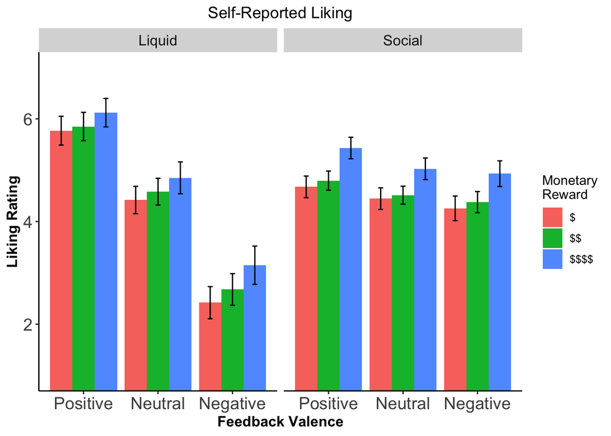

```r
#Omnibus ANOVA (Incentive Type x Valence x Monetary Reward)
anova.motive.E2<-ezANOVA(data = data.mot.sf.lf, dv = rating, wid = .(subID), within = c("Valence","IncentiveType","money"))

#Social Feedback ANOVA (Valence x Monetary Reward)
social.anova.motive.E2<-ezANOVA((data = data.mot.sf.lf %>% filter(IncentiveType == "Social")), dv = rating, wid = .(subID), within = c("Valence","money"))

#Liquid Feedback ANOVA (Valence x Monetary Reward)
liquid.anova.motive.E2<-ezANOVA((data = data.mot.sf.lf %>% filter(IncentiveType == "Liquid")), dv = rating, wid = .(subID), within = c("Valence","money"))

#Liking Ratings
#Liquid liking ratings
data.like.lf<-select(data.ratings.liquid, subID,
                 Juice_1Liking, Juice_2Liking, Juice_4Liking,
                 Neutral_1Liking, Neutral_2Liking, Neutral_4Liking,
                 Salt_1Liking, Salt_2Liking, Salt_4Liking) %>%
  pivot_longer(names_to = "liking", values_to = "rating", -subID) %>%
  separate(liking, into = c("Valence","misc"), sep = "_") %>%
  separate(misc, into = c("moneyreward", NA), sep = 1) %>%
  mutate(IncentiveType = "Liquid",
         rewCode = factor(moneyreward, levels = c(1,2,4), labels=c(-1,0,1)),
         money=factor(moneyreward, levels=c(1,2,4), labels=c("$","$$","$$$$")),
         Valence=factor(Valence, levels = c("Juice","Neutral","Salt"), labels = c("Positive","Neutral","Negative")),
         valCode = factor(Valence, levels=c("Positive","Neutral","Negative"), labels=c(1,0,-1)),
         incentiveCode = factor(IncentiveType, levels=c("Social","Liquid"), labels=c(0,1)))
data.like.lf$rewCode <- as.numeric(levels(data.like.lf$rewCode)[data.like.lf$rewCode])
data.like.lf$valCode <- as.numeric(levels(data.like.lf$valCode)[data.like.lf$valCode])
data.like.lf$incentiveCode <- as.numeric(levels(data.like.lf$incentiveCode)[data.like.lf$incentiveCode])

#Social liking ratings
data.like.sf<-select(data.ratings.social, subID,
                 HappyFace_1Liking, HappyFace_2Liking, HappyFace_4Liking,
                 NeutFace_1Liking, NeutFace_2Liking, NeutFace_4Liking,
                 SadFace_1Liking, SadFace_2Liking, SadFace_4Liking) %>%
  pivot_longer(names_to = "liking", values_to = "rating", -subID) %>%
  separate(liking, into = c("Valence","misc"), sep = "_") %>%
  separate(misc, into = c("moneyreward", NA), sep = 1) %>%
  mutate(IncentiveType = "Social",
         rewCode = factor(moneyreward, levels = c(1,2,4), labels=c(-1,0,1)),
         money=factor(moneyreward, levels=c(1,2,4), labels=c("$","$$","$$$$")),
         Valence=factor(Valence, levels = c("HappyFace","NeutFace","SadFace"), labels = c("Positive","Neutral","Negative")),
         valCode = factor(Valence, levels=c("Positive","Neutral","Negative"), labels=c(1,0,-1)),
         incentiveCode = factor(IncentiveType, levels=c("Social","Liquid"), labels=c(0,1)))
data.like.sf$rewCode <- as.numeric(levels(data.like.sf$rewCode)[data.like.sf$rewCode])
data.like.sf$valCode <- as.numeric(levels(data.like.sf$valCode)[data.like.sf$valCode])
data.like.sf$incentiveCode <- as.numeric(levels(data.like.sf$incentiveCode)[data.like.sf$incentiveCode])

#Merging Social + Liquid Feedback Dataframes
data.like.sf.lf <- rbind(data.like.lf, data.like.sf)

data.like.sf.lf.sum<-summarySEwithin2(data = data.like.sf.lf, measurevar = "rating",
                                 withinvars = c("Valence","money","IncentiveType"),
                                 idvar = "subID")

data.like.sf.lf.sum$Valence <-factor(data.like.sf.lf.sum$Valence, levels = c("Positive", "Neutral", "Negative"))
p.like.sf.lf<-ggplot(data = data.like.sf.lf.sum, aes(x = Valence, y = rating, fill = money)) +
  geom_bar(position=position_dodge(), stat = "identity") +
  coord_cartesian(ylim = c(1,7)) +
  geom_errorbar(position=position_dodge(.9),
                mapping = aes(ymin=rating-ci, ymax=rating+ci), width=.2) +
  xlab("Feedback Valence") + ylab("Liking Rating") + ggtitle("Self-Reported Liking") +
  scale_fill_discrete(name="Monetary\nReward") +
  theme(plot.title = element_text(hjust = 0.5), panel.grid.major = element_blank(), panel.grid.minor = element_blank(), panel.background = element_blank(), axis.line = element_line(colour = "black"),
    axis.title=element_text(size=12,face = "bold"),
    axis.text=element_text(size=14),
    legend.position="right",
    strip.text.x = element_text(size = 12)) +
  facet_grid(.~IncentiveType)
p.like.sf.lf
```

```r
#Summary of Liking Ratings
data.like.sf.lf.sum$Valence <- factor(data.like.sf.lf.sum$Valence, levels = c("Positive","Neutral","Negative"))
data.like.sf.lf.sum$money <-  factor(data.like.sf.lf.sum$money, levels = c("$","$$","$$$$"), labels = c("Low","Medium","High"))
liking.tab.E2 <- data.like.sf.lf.sum %>% select(Valence, money, IncentiveType, rating, sd) %>%
  pivot_wider(names_from = "IncentiveType", values_from = c("rating","sd")) %>%
  select(Valence, money, rating_Liquid, sd_Liquid, rating_Social, sd_Social) %>%
  kable(., format = "html", digits = 3, booktabs = T,
        col.names = c("Feedback Valence", "Monetary Reward", rep(c("Mean","SD"), times = 2)),
        caption = "Post-Task Liking Ratings") %>%
  kable_styling(full_width = F) %>%
  add_header_above(c(" " = 2, "Liquid" = 2, "Social" = 2)) %>%
  pack_rows("Negative", 1, 3) %>%
  pack_rows("Neutral", 4, 6) %>%
  pack_rows("Positive", 7, 9)
liking.tab.E2
```

Post-Task Liking Ratings

| Feedback Valence | Monetary Reward | Liquid Mean | Liquid SD | Social Mean | Social SD |
| --- | --- | --- | --- | --- | --- |
| **Negative** |  |  |  |  |  |
| Negative | Low | 2.419 | 1.351 | 4.257 | 1.034 |
| Negative | Medium | 2.676 | 1.330 | 4.378 | 0.887 |
| Negative | High | 3.149 | 1.610 | 4.932 | 1.082 |
| **Neutral** |  |  |  |  |  |
| Neutral | Low | 4.419 | 1.152 | 4.446 | 0.906 |
| Neutral | Medium | 4.581 | 1.125 | 4.514 | 0.754 |
| Neutral | High | 4.851 | 1.340 | 5.027 | 0.910 |
| **Positive** |  |  |  |  |  |
| Positive | Low | 5.770 | 1.209 | 4.676 | 0.908 |
| Positive | Medium | 5.851 | 1.188 | 4.797 | 0.806 |
| Positive | High | 6.122 | 1.193 | 5.432 | 0.904 |

```r
#Omnibus ANOVA (Incentive Type x Valence x Monetary Reward)
anova.liking.E2<-ezANOVA(data = data.like.sf.lf, dv = rating, wid = .(subID), within = c("Valence","IncentiveType","money"))

#Social Feedback ANOVA (Valence x Monetary Reward)
social.anova.liking.E2<-ezANOVA((data = data.like.sf.lf %>% filter(IncentiveType == "Social")), dv = rating, wid = .(subID), within = c("Valence","money"))

#Liquid Feedback ANOVA (Valence x Monetary Reward)
liquid.anova.liking.E2<-ezANOVA((data = data.like.sf.lf %>% filter(IncentiveType == "Liquid")), dv = rating, wid = .(subID), within = c("Valence","money"))

#Formatting Ind Diff Dataframe
data.ratings.ind<-read.csv(file = indiv.path, sep=",")
data.ratings.ind <- data.ratings.ind %>% filter(!subID %in% sub.exclude)

#BISBAS
BISBAS.E2 <- data.ratings.ind %>% select(subID, BAS_Drive, BAS_Fun, BAS_Reward, BAS_Total, BIS)
BISBAS.E2.means <- BISBAS.E2 %>%
  dplyr::summarise("BAS Reward" = mean(BAS_Reward), "BAS Reward (sd)" = sd(BAS_Reward), "BAS Fun" = mean(BAS_Fun), "BAS Fun (sd)" = sd(BAS_Fun),
                   "BAS Drive" = mean(BAS_Reward), "BAS Drive (sd)" = sd(BAS_Drive), "BIS" = mean(BIS), "BIS (sd)" = sd(BIS, na.rm = T)) %>%
  kable(format = "html", caption = "BIS/BAS Means") %>%
  kable_styling(full_width = F)
BISBAS.E2.means
```

BIS/BAS Means

| BAS Reward | BAS Reward (sd) | BAS Fun | BAS Fun (sd) | BAS Drive | BAS Drive (sd) | BIS | BIS (sd) |
| --- | --- | --- | --- | --- | --- | --- | --- |
| 17.54054 | 1.980654 | 12.09459 | 2.439228 | 17.54054 | 2.417732 | 21.16216 | NA |

```r
#DARS
DARS.E2 <- data.ratings.ind %>% select(subID, DARS_Hobby, DARS_FoodDrink, DARS_SocialActivity, DARS_SensoryExp, DARS_Total)
DARS.E2.means <- DARS.E2 %>%
  dplyr::summarise("DARS Hobby" = mean(DARS_Hobby), "DARS Hobby (sd)" = sd(DARS_Hobby), "DARS Food" = mean(DARS_FoodDrink), "DARS Food (sd)" = sd(DARS_FoodDrink),
                   "DARS Social" = mean(DARS_SocialActivity), "DARS Social (sd)" = sd(DARS_SocialActivity), "DARS Sensory" = mean(DARS_SensoryExp),
                   "DARS Sensory (sd)" = sd(DARS_SensoryExp)) %>%
  kable(format = "html", caption = "DARS Means") %>%
    kable_styling(full_width = F)
DARS.E2.means
```

DARS Means

| DARS Hobby | DARS Hobby (sd) | DARS Food | DARS Food (sd) | DARS Social | DARS Social (sd) | DARS Sensory | DARS Sensory (sd) |
| --- | --- | --- | --- | --- | --- | --- | --- |
| 14.75676 | 2.298366 | 12.54054 | 3.043921 | 13.31081 | 2.363685 | 16.55405 | 3.875253 |

```r
#MASQ
MASQ <- data.ratings.ind %>%  select(subID, MASQ_anhed, MASQ_anhed8)
MASQ.means <- MASQ %>% dplyr::summarise(mean_MASQ_anhed = mean(MASQ_anhed), sd_MASQ_anhed = sd(MASQ_anhed),
                                        mean_MASQ_anhed8 = mean(MASQ_anhed8), sd_MASQ_anhed8 = sd(MASQ_anhed8)) %>%
  kable(format = "html", caption = "MASQ Means")
MASQ.means
```

MASQ Means

| mean_MASQ_anhed | sd_MASQ_anhed | mean_MASQ_anhed8 | sd_MASQ_anhed8 |
| --- | --- | --- | --- |
| 52.12162 | 12.75368 | 15.37838 | 4.764891 |